# total_project_17_04_20

### Name: GEORGIOS ORFANAKIS

### Matriculation No: 1903446

### Module: ADVANCED DATA SCIENCE (CMM536)

### Coursework: Image recognition in the Oil & Gas Industry

# CONTENTS:

# PART1

## 1. Introduction

## 2. Data Praparation

## 3. Feature extraction-Class decomposition

### 3.1 FEATURE EXTRACTION --1-- HOG feature extraction

### 3.2 CLUSTER DECOMPOSITION --KMEANS-- ON HOG'S FEATURES

### 3.3 CLUSTER DECOMPOSITION --Rule of thump with Agglomerative Clustering-- ON HOG'S FEATURES

### 3.4 FEATURE EXTRACTION --2-- PCA feature extraction

### 3.5 CLUSTER DECOMPOSITION --KMEANS-- ON PCA FEATURES

### 3.6 CLUSTER DECOMPOSITION --Rule of thump with Agglomerative Clustering-- ON PCA FEATURES

## 4. IMAGE AUGMENTATION

## 5. DATA AUGMENTATION

### 5.1 Augmentation on HOG data

### 5.2 Augmentation on PCA data

### 5.3 Augmentation on k-means decomposed HOG data

### 5.4 Augmentation on agglomerative clustering decomposed HOG data

### 5.5 Augmentation on k-means decomposed PCA data

### 5.6 Augmentation on agglomerative clustering decomposed PCA data

# PART2

## 4. CONVOLUTIONAL NEURAL NETWORKS CLASSIFICATION

### 4.1 CNN on IMAGE AUGMENTED DATASET

### 4.2 CNN on second IMAGE AUGMENTED DATASET

## 5. RESULTS-DISCUSSION

## 6. FUTURE CHALLENGES

## 7. COMMENTS

# PART1

## 1. Introduction

The aim of this coursework is building an image recognition system of P&ID images of the oil & gas industry. An initial repository of images was created with the images initially provided. Then a pre-processing of the images began to get them into the appropriate format to be used for the main processing procedures. The pre-processing involved procedures such as binarizing, turning the images to greyscale and stacking them together into a new repository. It is important to notice that images were initially belonging to certain categories here mentioned as classes or targets. So, this repository included these classes too, which were also assigned an integer number for ease of use.

The main processing procedures involved extracting the important features of these images through the methods of HOG and PCA. The data that came out of these feature extracting methods was augmented using basically two techniques, Condensed Nearest Neighbour, for under sampling, and random oversampling, in order for the classes to be balanced. Another undersampling method used only for one dataset (agglomerative clustering decomposed PCA features dataset) was one sided selection over just the majority class.

Another main processing procedure was image augmentation. For this the images and not the extracted features, were directly tuned in such ways that for each image already existing new ones were created that were for example rotated or with noise added on them. The final two new repositories created were imbalanced, but with more images to each new category and with added variety in them.

Another main procedure was class decomposition. Specifically, two ways of class decomposition were followed, k-means clustering and hierarchical agglomerative clustering. For both the procedures, the existing classes of images were broken down to subclasses according to certain rules and algorithms so that indirectly the feature extracted datasets were better balanced. For the two decomposed datasets of the HOG feature data augmentation took place.

At the end of PART-1 there were : 1 augmented HOG feature dataset, 1 augmented PCA feature dataset, 2 class decomposed augmented HOG feature datasets with different decomposition methods used, 2 class decomposed augmented PCA feature datasets with different decomposition methods used, 1 image augmented dataset. One more image augmented dataset is created in PART-2. In total, **8 new datasets were created and were further used for classification in PART-2**.

After all these, followed the main part of the project which was building classifiers in order to be able to predict the class of new images according to the existing datasets of extracted augmented features or augmented images. For the case of augmented extracted features, the classifiers used were SVM, Random Forest, Decision Trees and Neural Networks. For the case of augmented images Convolutional Neural Networks were used. The results were pretty encouraging and conclusions were based on certain scientifically accredited metrics. Results and conclusion are officially presented and explained at the end of this project.

## 2. DATA PREPARATION

Images from a zip file were extracted and put in Jupyter notebook filesystem. The directory of each image was drawn and used for each image to be drawn and processed. The pixels of the images were modified for the image to be turned into greyscale and be binarized. The binarization of every image in a numpy array was done according to a specified threshold (=220). Images were stored in a list consecutively. Another repository was created were the class/target of every image was kept. A pandas dataframe was created were both the processed pixels and the targets/classes were stored. These 3 repositories acted as the base from which feature extraction and image augmentation would be initialized. Turning the images to grayscale meant basically that they were turned into a 2D grid of pixels with the Standard format meaning pixel values varying from 0 (black) to 255 (white) with 254 grey values in between. The grayscale images were then converted into binary (black/white) image based on a threshold which is useful to improve the quality of an image and to refine shapes.

```python
#### Packages import
import cv2
import os
import glob
import pathlib
import numpy as np
```

```python
#### Sumbols zip file imported and extracted
'''import zipfile as zf
files = zf.ZipFile("Symbols.zip", 'r')
files.extractall('directory to extract')
files.close()'''
```

```
'import zipfile as zf\nfiles = zf.ZipFile("Symbols.zip", \'r\')\nfiles.extractall(\'directory to extract\')\nfiles.close()'
```

```python
### Directory of extraction
img_dir = 'C:\\Users\\User\\tryProj1\\in_dir\\Symbols'
```

```python
#### Walk through directories

for dirnames in os.walk(img_dir):
    print('Directories:', dirnames)

    print() # gives blank line
```

```python
#### list directories where images are
Mult_dir = os.listdir(img_dir)
type(Mult_dir)
print()
print(Mult_dir)
```

```
['.ipynb_checkpoints', 'Arrowhead', 'Arrowhead + Triangle', 'Barred Tee', 'Box', 'Continuity Label', 'Control', 'Control Valve', 'Control Valve Angle Choke', 'Control Valve Globe', 'DB&BBV', 'DB&BBV + Valve Check', 'DB&BPV', 'Deluge', 'ESDV Valve Ball', 'ESDV Valve Butterfly', 'ESDV Valve Slab Gate'…
```

```python
#### create strings of each directory in symbols folder and append them in a list
listOfDirs = []
for i in Mult_dir:
    x = os.path.join(img_dir, i)
    listOfDirs.append(x)
print(listOfDirs)
```

```
['C:\\Users\\User\\tryProj1\\in_dir\\Symbols\\.ipynb_checkpoints', 'C:\\Users\\User\\tryProj1\\in_dir\\Symbols\\Arrowhead', 'C:\\Users\\User\\tryProj1\\in_dir\\Symbols\\Arrowhead + Triangle', 'C:\\Users\\User\\tryProj1\\in_dir\\Symbols\\Barred Tee', 'C:\\Users\\User\\tryProj1\\in_dir\\Symbols\\Box',…
```

```python
#### function to return a list of filenames for all jpg images in a directory
def get_imlist(path):
  """  Returns a list of filenames for all jpg images in a directory. """

  return [os.path.join(path,f) for f in os.listdir(path) if f.endswith('.jpg')]
```

```python
#### store images in greyscale from each directory
targetBase = []
imgData = []
for path in listOfDirs:
    data_path = get_imlist(path)
    for i in data_path:
        files = glob.glob(i)
        x = pathlib.PurePath(i)
        y = x.parent.name
        targetBase.append(y)
        for f1 in files:
            img = cv2.imread(f1, 0)
            imgData.append(img)
```

```python
#### Verification1 of image storage
print(len(imgData))
#print(str(imgData))
print(imgData[0])
print(imgData[-1])
```

```
2432
[[  0   0   0 ...   0   0   0]
 [255 255 255 ... 255 255 255]
 [255 255 255 ... 255 255 255]
 ...
 [255 255 255 ... 255 255 255]
 [255 255 255 ... 255 255 255]
 [255 255 255 ... 255 255 255]]
[[255 255 255 ... 255 255 255]
 [255 255 255 ... 255 255 255]
 [255 255 255 ... 255 255 255]
 ...
 [255 255 255 ... 255 255 255]
 [255 255 255 ... 255 255 255]
 [255 255 255 ... 255 255 255]]
```

```python
#### import packages
!pip install opencv-python
!pip install matplotlib

import numpy as np
import matplotlib.pyplot as plt
```

```python
#### binarisation function
def binarise(img, threshold):
    '''This function binarises an image in a numpy array according to the specified threshold'''

    for i in range(img.shape[0]):
        for j in range(img.shape[1]):
            if img[i,j]< threshold:
               img[i,j] = 0
            else:
               img[i,j] = 255
    plt.imshow(img, cmap='Greys_r')
    return img

# print([binarise(x, 220) for x in data])
```

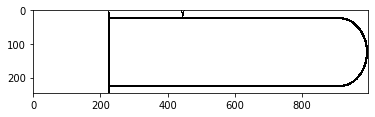

```python
#### Binarize and store all images using list comprehension
data_Bin = [binarise(x, 220) for x in imgData[:]]
```

```python
#### Verification of binarization
print(len(data_Bin))
print(type(data_Bin))
data_Bin[-1]
print(data_Bin[125].shape)
```

```
2432
<class 'list'>
(18, 32)
```

```python
#### creation of unique indices for targets
import numpy as np
#print(targetBase)
tBaseCopy = targetBase.copy()
tBaseCopy, indices = np.unique(tBaseCopy, return_inverse=True)
# print(tBaseCopy)
#print(tBaseCopy[indices])
#print(indices)
print(len(indices))
print(indices[2])
print(indices[241])
# Create reshaped indices. inds will be the target/class from now on
indicesCP = indices.copy()
print()
#print(indicesCP[0:240])
print()
inds =indicesCP.reshape(-1,1)
print(inds[239:242])
```

```
2432
0
1


[[0]
 [1]
 [1]]
```

```python
#### repository of binarised images and their target
import pandas as pd
data_BinC = data_Bin.copy()
df1 = pd.DataFrame(columns = ['imgBdata', 'target', 'target_name'])
print(df1)
for i in range(len(indices)):
    df1 = df1.append({'imgBdata': data_BinC[i], 'target': indices[i], 'target_name':targetBase[i]},ignore_index=True)
```

```
Empty DataFrame
Columns: [imgBdata, target, target_name]
Index: []
```

```python
#### proof of repository creation
df1[238:244]
```

|  | imgBdata | target | target_name |
| --- | --- | --- | --- |
| 238 | [[255, 255, 255, 255, 255, 255, 255, 255, 255,... | 0 | Arrowhead |
| 239 | [[255, 255, 255, 255, 255, 255, 255, 0, 255, 2... | 0 | Arrowhead |
| 240 | [[255, 255, 0, 0, 0, 0, 0, 0, 255, 255, 255, 2... | 1 | Arrowhead + Triangle |
| 241 | [[255, 255, 255, 255, 255, 255, 255, 255, 255,... | 1 | Arrowhead + Triangle |
| 242 | [[255, 255, 255, 255, 255, 255, 255, 255, 255,... | 1 | Arrowhead + Triangle |
| 243 | [[255, 255, 255, 255, 255, 255, 255, 255, 255,... | 1 | Arrowhead + Triangle |

```python
#### count items in indices
x_list = indicesCP.tolist()
from collections import Counter

c_items = Counter(x_list)
print(type(c_items))
print(c_items)
print(c_items[0])
```

```
<class 'collections.Counter'>
Counter({24: 392, 22: 285, 0: 240, 31: 173, 9: 127, 33: 126, 4: 116, 11: 113, 36: 88, 1: 83, 27: 74, 32: 71, 13: 65, 19: 61, 18: 46, 20: 43, 25: 42, 29: 40, 10: 39, 35: 28, 30: 27, 37: 24, 8: 23, 17: 17, 5: 13, 16: 12, 23: 10, 15: 9, 3: 7, 14: 7, 26: 6, 6: 5, 12: 4, 21: 4, 34: 4, 38: 4, 7: 2, 2: 1, …
240
```

```python
#### create list with just the sum of each target
classdist = []
for i in c_items:
    classdist.append(c_items[i])

# verification classdist list creation
print(type(classdist))
print(type(classdist[i]))
print(len(classdist))
print(classdist)
print(classdist[0])
```

```
<class 'list'>
<class 'int'>
39
[240, 83, 1, 7, 116, 13, 5, 2, 23, 127, 39, 113, 4, 65, 7, 9, 12, 17, 46, 61, 43, 4, 285, 10, 392, 42, 6, 74, 1, 40, 27, 173, 71, 126, 4, 28, 88, 24, 4]
240
```

```python
#### Create the clusters
import math
Avg = sum(classdist)/len(classdist)
print('Avg: ', Avg)
## Then we can calculate ki for each class
for i,c in enumerate(classdist):
    print('k_'+str(i)+'=', (c/Avg)+1)


cluster = []
## Calculating the number of clusters to decompose each class
for i,c in enumerate(classdist):
    print('Clusters for class '+str(i)+':', math.floor((c/Avg)+1))
    cluster.append(math.floor((c/Avg)+1))
```

```
Avg:  62.35897435897436
k_0= 4.848684210526316
k_1= 2.331003289473684
k_2= 1.0160361842105263
k_3= 1.1122532894736843
k_4= 2.8601973684210527
k_5= 1.208470394736842
k_6= 1.0801809210526316
k_7= 1.0320723684210527
k_8= 1.3688322368421053
k_9= 3.036595394736842
k_10= 1.6254111842105263
k_11= 2.8120888157894735
k_12= 1.0641447368421053
k_13= 2.0423519736842106
k_14= 1.1122532894736843
k_15= 1.1443256578947367
k_16= 1.1924342105263157
k_17= 1.2726151315789473
k_18= 1.7376644736842106
k_19= 1.9782072368421053
k_20= 1.6895559210526316
k_21= 1.0641447368421053
k_22= 5.5703125
k_23= 1.1603618421052633
k_24= 7.286184210526316
k_25= 1.6735197368421053
k_26= 1.096217105263158
k_27= 2.1866776315789473
k_28= 1.0160361842105263
k_29= 1.6414473684210527
k_30= 1.4329769736842106
k_31= 3.7742598684210527
k_32= 2.138569078947368
k_33= 3.020559210526316
k_34= 1.0641447368421053
k_35= 1.4490131578947367
k_36= 2.411184210526316
k_37= 1.3848684210526316
k_38= 1.0641447368421053
```

[output cut: 24 more lines]

```
Clusters for class 24: 7
Clusters for class 25: 1
Clusters for class 26: 1
Clusters for class 27: 2
Clusters for class 28: 1
Clusters for class 29: 1
Clusters for class 30: 1
Clusters for class 31: 3
Clusters for class 32: 2
Clusters for class 33: 3
Clusters for class 34: 1
Clusters for class 35: 1
Clusters for class 36: 2
Clusters for class 37: 1
Clusters for class 38: 1
```

## 3. Feature extraction-Class decomposition

Two different image feature extraction algorithms were used: HOGs and PCA. The features extracted of each image in each case were then concatenated with the target/class the image initially belonged to and stored in a repository. Each of these two repositories underwent:

```
1. class decomposition
2. data augmentation
```

After each class decomposition follows proof of the decomposition of the class through graphs. Two methods of class decomposition are followed:

```
1. K-means clustering
2. Agglomerative clustering
```

Class Decomposition:

Kmeans clustering: It was used for class decomposition for features out of HOG algorithm and PCA. Class decomposition works by breaking down existing/predetermined classes. It is a form of equalising imbalanced classes.

Agglomerative Clustering following the rule of thumb: It was used on HOG’s and PCA features. It recursively merges the pair of clusters that minimally increases a given linkage distance. Linkage distance used was ‘ward’ which minimizes the variance of the clusters being merged. Rule of thumb is a simple way and follows the equation to find the number of clusters to be implemented for each class/target and follows the equation k = sqrt(n/2), where n is the number of objects.

### 3.1 FEATURE EXTRACTION --1-- HOG feature extraction

```python
#### Obtaining the HOG gradients of an image
from skimage import feature
class HOG:
    def __init__(self, orientations = 9, pixelsPerCell = (8, 8),
        cellsPerBlock = (2, 2), transform = False):
        self.orienations = orientations
        self.pixelsPerCell = pixelsPerCell
        self.cellsPerBlock = cellsPerBlock
        self.transform = transform
    def describe(self, image):
        hist = feature.hog(image, orientations = self.orienations,
            pixels_per_cell = self.pixelsPerCell,
            cells_per_block = self.cellsPerBlock,
            transform_sqrt = self.transform,
            block_norm = 'L2-Hys')
        return hist

HOG_Hist_data = []
#repo = []
for img in data_Bin:
    img = cv2.resize(img, (100,100))
    #img = cv2.imread(img)
    hog = HOG(orientations = 9, pixelsPerCell = (8, 8), cellsPerBlock = (2, 2), transform = True)
    hist = hog.describe(img)
    print('HOG Features for the image:')
    print(hist)
    print('Size of the HOG Features for the image:', hist.shape)
    HOG_Hist_data.append(hist)
```

```python
#### proof of HOG features extraction application on dataset
print(type(HOG_Hist_data))
print(len(HOG_Hist_data))
print(HOG_Hist_data[:3])
```

```
<class 'list'>
2432
[array([0., 0., 0., ..., 0., 0., 0.]), array([0.        , 0.        , 0.        , ..., 0.22524425, 0.15582402,
       0.19875606]), array([0., 0., 0., ..., 0., 0., 0.])]
```

```python
#### creation of duplicate of HOG's data and turn to array
HOG_Hist_dataC = HOG_Hist_data.copy()
hogARR = np.array(HOG_Hist_dataC)
print(type(hogARR))
print(len(hogARR))
print(hogARR[:3])
print(hogARR.shape)
```

```
<class 'numpy.ndarray'>
2432
[[0.         0.         0.         ... 0.         0.         0.        ]
 [0.         0.         0.         ... 0.22524425 0.15582402 0.19875606]
 [0.         0.         0.         ... 0.         0.         0.        ]]
(2432, 4356)
```

```python
#### Copy of the HOG's array
hogARRC = hogARR.copy()
hogMix = np.concatenate((hogARRC,inds), axis=1)

print(hogMix.shape)
print(hogMix[:5])
print(hogMix[238:242])
```

```
(2432, 4357)
[[0.         0.         0.         ... 0.         0.         0.        ]
 [0.         0.         0.         ... 0.15582402 0.19875606 0.        ]
 [0.         0.         0.         ... 0.         0.         0.        ]
 [0.44286097 0.26352433 0.37754504 ... 0.         0.         0.        ]
 [0.02909662 0.19727947 0.25985485 ... 0.         0.         0.        ]]
[[0.         0.         0.         ... 0.         0.         0.        ]
 [0.         0.         0.         ... 0.         0.         0.        ]
 [0.38654283 0.03081544 0.27494646 ... 0.         0.         1.        ]
 [0.         0.         0.         ... 0.30430718 0.30430718 1.        ]]
```

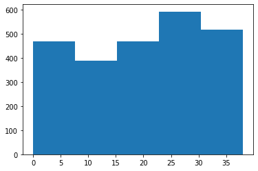

```python
import matplotlib.pyplot as plt
plt.hist(hogMix[:,-1],bins=5)
print()
```

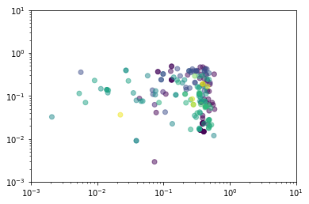

```python
#### Plotting the data
plt.scatter(hogMix[:,0], hogMix[:,150], c=hogMix[:,-1], alpha=0.5) # c for color, alpha for transparent points
plt.xlim(0.001, 10)
plt.ylim(0.001, 10)
plt.xscale('log')
plt.yscale('log')
plt.show()
```

### 3.2 CLUSTER DECOMPOSITION --KMEANS-- ON HOG'S FEATURES

```python
newTargetHOG = []
from sklearn.cluster import KMeans
for i,c in enumerate(classdist):

    X = hogMix[np.where(hogMix[:,-1]==i)][:,:-1] # Find instances of the class
    y = np.zeros((c,1))+i
    z = tBaseCopy[i]
    nclusters = math.floor((c/Avg)+1) # Calculate number of clusters
    print('Clusters to decompose class '+str(i)+':', nclusters)
    print(z)
    if nclusters>1:
        kmeans = KMeans(n_clusters=nclusters).fit(X)
    ## add to the last column decimals for the new class
        for j,n in enumerate(X):
            y[j]=y[j]+(kmeans.labels_[j]/10) # divide by 10 so that it gets ,!added as decimal
        print('Decomposed version of class '+str(i)+':')
        print(np.concatenate((X,y),axis=1))
    if i==0: # If this is the first time, copy the first class into a new repo
        repo_decompHOG = np.concatenate((X,y),axis=1).copy()
        f=y.copy()
        newTargetHOG.append(f)
    else: # stack the new into the existing
        repo_decompHOG = np.vstack((repo_decompHOG,np.concatenate((X,y),axis=1)))
        f=y.copy()
        newTargetHOG.append(f)
#print('Decomposed repo')
#print(repo_decompHOG)
```

```python
#### proof of HOG's features class decomposition
print(type(repo_decompHOG))
print(len(repo_decompHOG))
print(repo_decompHOG[239:245])
```

```
<class 'numpy.ndarray'>
2432
[[0.         0.         0.         ... 0.         0.         0.2       ]
 [0.38654283 0.03081544 0.27494646 ... 0.         0.         1.        ]
 [0.         0.         0.         ... 0.30430718 0.30430718 1.1       ]
 [0.45960311 0.08840053 0.11325908 ... 0.         0.         1.        ]
 [0.         0.         0.         ... 0.         0.         1.        ]
 [0.29783258 0.09001104 0.10466475 ... 0.         0.         1.1       ]]
```

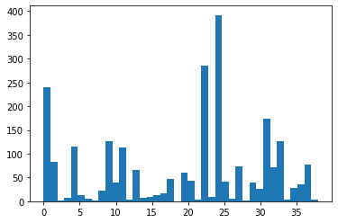

```python
#### Plotting the histogram of the new class distribution
plt.hist(repo_decompHOG[:,-1],bins=40)
plt.show()
```

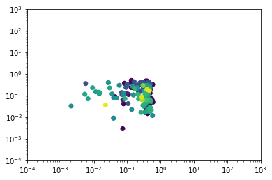

```python
#### Plotting the decomposed data
plt.scatter(repo_decompHOG[:,0], repo_decompHOG[:,150], c=repo_decompHOG[:,-1]/4)
plt.xlim(0.0001, 1000)
plt.ylim(0.0001, 1000)
plt.xscale('log')
plt.yscale('log')
plt.show()
```

```python
nctHOG = []
for i in range(len(newTargetHOG)):
    for j in range(len(newTargetHOG[i])):
        name = tBaseCopy[i] + '_' + str(newTargetHOG[i][j])
        nctHOG.append(name)
print(len(nctHOG))
print(nctHOG[100:110])
```

```
2432
['Arrowhead_[0.2]', 'Arrowhead_[0.3]', 'Arrowhead_[0.3]', 'Arrowhead_[0.3]', 'Arrowhead_[0.1]', 'Arrowhead_[0.3]', 'Arrowhead_[0.3]', 'Arrowhead_[0.1]', 'Arrowhead_[0.3]', 'Arrowhead_[0.3]']
```

```python
nctHOGCopy = nctHOG.copy()
nctHOGCopy, indnctHOG = np.unique(nctHOGCopy, return_inverse=True)
print(len(nctHOGCopy))
print(len(indnctHOG))
print(indnctHOG[123:135])
```

```
65
2432
[3 4 4 4 4 2 2 4 4 4 4 3]
```

Above we see that 65 classes exist now in the dataset. Below the dataset of the decomposed HOG features is created

```python
import pandas as pd

df3 = pd.DataFrame(columns = ['hog', 'new_target', 'new_target_INT','new_target_name'])
for i in range(len(indnctHOG)):
    df3 = df3.append({'hog': repo_decompHOG[i,:-1], 'new_target': repo_decompHOG[i,-1],'new_target_INT':indnctHOG[i], 'new_target_name':nctHOG[i]},ignore_index=True)

df3[500:520]
```

|  | hog | new_target | new_target_INT | new_target_name |
| --- | --- | --- | --- | --- |
| 500 | [0.0, 0.0, 0.0, 0.0, 0.0, 0.0, 0.0, 0.0, 0.0, ... | 9.1 | 15 | DB&BBV_[9.1] |
| 501 | [0.0, 0.0, 0.0, 0.0, 0.0, 0.0, 0.0, 0.0, 0.0, ... | 9.1 | 15 | DB&BBV_[9.1] |
| 502 | [0.0, 0.0, 0.0, 0.0, 0.0, 0.0, 0.0, 0.0, 0.0, ... | 9.2 | 16 | DB&BBV_[9.2] |
| 503 | [0.0, 0.0, 0.0, 0.0, 0.0, 0.0, 0.0, 0.0, 0.0, ... | 9.1 | 15 | DB&BBV_[9.1] |
| 504 | [0.0, 0.0, 0.0, 0.0, 0.0, 0.0, 0.0, 0.0, 0.0, ... | 9.0 | 17 | DB&BBV_[9.] |
| 505 | [0.0, 0.0, 0.0, 0.0, 0.0, 0.0, 0.0, 0.0, 0.0, ... | 9.0 | 17 | DB&BBV_[9.] |
| 506 | [0.0, 0.0, 0.0, 0.0, 0.0, 0.0, 0.0, 0.0, 0.0, ... | 9.1 | 15 | DB&BBV_[9.1] |
| 507 | [0.0, 0.0, 0.0, 0.0, 0.0, 0.0, 0.0, 0.0, 0.0, ... | 9.0 | 17 | DB&BBV_[9.] |
| 508 | [0.0, 0.0, 0.0, 0.0, 0.0, 0.0, 0.0, 0.0, 0.0, ... | 9.1 | 15 | DB&BBV_[9.1] |
| 509 | [0.0, 0.0, 0.0, 0.0, 0.0, 0.0, 0.0, 0.0, 0.0, ... | 9.1 | 15 | DB&BBV_[9.1] |
| 510 | [0.0, 0.0, 0.0, 0.0, 0.0, 0.0, 0.0, 0.0, 0.0, ... | 9.1 | 15 | DB&BBV_[9.1] |
| 511 | [0.0, 0.0, 0.0, 0.0, 0.0, 0.0, 0.0, 0.0, 0.0, ... | 9.1 | 15 | DB&BBV_[9.1] |
| 512 | [0.0, 0.0, 0.0, 0.0, 0.0, 0.0, 0.0, 0.0, 0.0, ... | 9.1 | 15 | DB&BBV_[9.1] |
| 513 | [0.22104188609076958, 0.0, 0.09049041337645905... | 9.2 | 16 | DB&BBV_[9.2] |
| 514 | [0.0, 0.0, 0.0, 0.0, 0.0, 0.0, 0.0, 0.0, 0.0, ... | 9.1 | 15 | DB&BBV_[9.1] |
| 515 | [0.0, 0.0, 0.0, 0.0, 0.0, 0.0, 0.0, 0.0, 0.0, ... | 9.1 | 15 | DB&BBV_[9.1] |
| 516 | [0.0, 0.0, 0.0, 0.0, 0.0, 0.0, 0.0, 0.0, 0.0, ... | 9.1 | 15 | DB&BBV_[9.1] |
| 517 | [0.0, 0.0, 0.0, 0.0, 0.0, 0.0, 0.0, 0.0, 0.0, ... | 9.1 | 15 | DB&BBV_[9.1] |
| 518 | [0.0, 0.0, 0.0, 0.0, 0.0, 0.0, 0.0, 0.0, 0.0, ... | 9.1 | 15 | DB&BBV_[9.1] |
| 519 | [0.0, 0.0, 0.0, 0.0, 0.0, 0.0, 0.0, 0.0, 0.0, ... | 9.1 | 15 | DB&BBV_[9.1] |

Here we see a brief presentation of a random part of the created edcomposed dataset which includes the extracetd features, the new sublasses, their assignment to new classes for the purpose of later on augmentation and classification as well as the original class in text with the sublclass notification at the end.

### 3.3 CLUSTER DECOMPOSITION --Rule of thump with Agglomerative Clustering-- ON HOG'S FEATURES

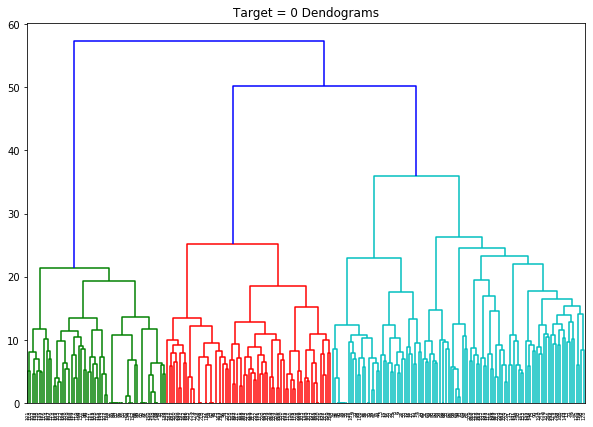

```python
#### Dendrogram of cluster 0

import scipy.cluster.hierarchy as shc
Z = hogMix[np.where(hogMix[:,-1]==0)][:,:-1]
plt.figure(figsize=(10, 7))
plt.title("Target = 0 Dendograms")
dend = shc.dendrogram(shc.linkage(Z, method='ward'))
```

Here affinity='euclidean', linkage='ward' are used. linkage criterion 'ward' is used which minimizes the variance of the clusters being merged.

```python
AGC_Hog_target =[]
from sklearn.cluster import AgglomerativeClustering
import math
for i,c in enumerate(classdist):

    X = hogMix[np.where(hogMix[:,-1]==i)][:,:-1] # Find instances of the class
    y = np.zeros((c,1))+i
    nclusters = math.floor((math.sqrt(len(hogMix[np.where(hogMix[:,-1]==i)][:,:])/2)+1)) # Calculate number of clusters with Rule of thumb
    print('Clusters to decompose class '+str(i)+':', nclusters)
    z = tBaseCopy[i]
    if nclusters>1:
        AGC = AgglomerativeClustering(n_clusters = nclusters, affinity='euclidean', linkage='ward')
        #AGC = KMeans(n_clusters=nclusters).fit(X)
        AGC.fit_predict(X)
    ## add to the last column decimals for the new class
        for j,n in enumerate(X):
            y[j]=y[j]+(AGC.labels_[j]/10) # divide by 10 so that it gets ,!added as decimal
        print('Decomposed version of class '+str(i)+':')
        print(z)
        print(np.concatenate((X,y),axis=1))
    if i==0: # If this is the first time, copy the first class into a new repo
        repo_decompAGC = np.concatenate((X,y),axis=1).copy()
        f=y.copy()
        AGC_Hog_target.append(f)
    else: # stack the new into the existing
        repo_decompAGC = np.vstack((repo_decompAGC,np.concatenate((X,y),axis=1)))
        f=y.copy()
        AGC_Hog_target.append(f)
#print('Decomposed repo')
#print(repo_decompAGC)
```

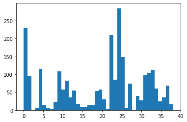

```python
#### Plotting the histogram of the new class distribution
plt.hist(repo_decompAGC[:,-1],bins=40)
plt.show()
```

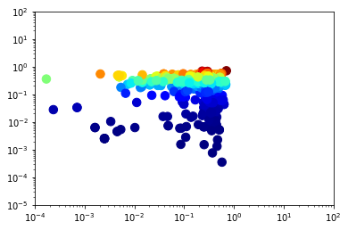

```python
#### Plotting the decomposed data
plt.scatter(repo_decompAGC[:,0], repo_decompAGC[:,4], c=repo_decompAGC[:,4], s=90, cmap="jet")
plt.xlim(0.0001, 100)
plt.ylim(0.00001, 100)
plt.xscale('log')
plt.yscale('log')
plt.show()
```

```python
AGCnHOG = []
for i in range(len(newTargetHOG)):
    for j in range(len(newTargetHOG[i])):
        name = tBaseCopy[i] + '_' + str(AGC_Hog_target[i][j])
        AGCnHOG.append(name)
print(len(AGCnHOG))
print(AGCnHOG[220:245])
```

```
2432
['Arrowhead_[0.2]', 'Arrowhead_[0.2]', 'Arrowhead_[0.2]', 'Arrowhead_[0.2]', 'Arrowhead_[0.2]', 'Arrowhead_[0.]', 'Arrowhead_[0.]', 'Arrowhead_[0.]', 'Arrowhead_[0.2]', 'Arrowhead_[0.]', 'Arrowhead_[0.5]', 'Arrowhead_[0.5]', 'Arrowhead_[0.3]', 'Arrowhead_[0.3]', 'Arrowhead_[0.3]', 'Arrowhead_[0.5]',…
```

```python
AGCnHOGCopy = AGCnHOG.copy()
AGCnHOGCopy, indAGCnHOG = np.unique(AGCnHOGCopy, return_inverse=True)
print(len(AGCnHOGCopy))
print(len(indAGCnHOG))
print(indAGCnHOG[100:120])
```

```
195
2432
[ 8 17 17  7 17  7  7 17  7  7  7 11 16  7  7  7 17  7 17  7]
```

We see here that the dataset has now 195 classes

```python
import pandas as pd
#data_BinC = data_Bin.copy()
df4 = pd.DataFrame(columns = ['hogAgg', 'new_target', 'new_target_INT','new_target_name'])
for i in range(len(indAGCnHOG)):
    df4 = df4.append({'hogAgg': repo_decompAGC[i,:-1], 'new_target': repo_decompAGC[i,-1],'new_target_INT':indAGCnHOG[i], 'new_target_name':AGCnHOG[i]},ignore_index=True)

df4[570:589]
```

|  | hogAgg | new_target | new_target_INT | new_target_name |
| --- | --- | --- | --- | --- |
| 570 | [0.24627735483082502, 0.11696325214612784, 0.0... | 9.0 | 52 | DB&BBV_[9.] |
| 571 | [0.0, 0.0, 0.0, 0.0, 0.0, 0.0, 0.0, 0.0, 0.0, ... | 9.0 | 52 | DB&BBV_[9.] |
| 572 | [0.005695862169578728, 0.15023205029679174, 0.... | 9.1 | 45 | DB&BBV_[9.1] |
| 573 | [0.4145957675879272, 0.13886137701224122, 0.41... | 9.5 | 49 | DB&BBV_[9.5] |
| 574 | [0.0, 0.0, 0.0, 0.0, 0.0, 0.0, 0.0, 0.0, 0.0, ... | 9.0 | 52 | DB&BBV_[9.] |
| 575 | [0.0, 0.0, 0.22003376482519965, 0.0, 0.4356648... | 9.1 | 45 | DB&BBV_[9.1] |
| 576 | [0.0, 0.0, 0.0, 0.0, 0.0, 0.0, 0.0, 0.0, 0.0, ... | 9.0 | 52 | DB&BBV_[9.] |
| 577 | [0.0, 0.0, 0.0, 0.0, 0.0, 0.0, 0.0, 0.0, 0.0, ... | 9.0 | 52 | DB&BBV_[9.] |
| 578 | [0.039690538156089396, 0.1256676583537301, 0.4... | 9.1 | 45 | DB&BBV_[9.1] |
| 579 | [0.0, 0.0, 0.0, 0.0, 0.4245562735732296, 0.0, ... | 9.1 | 45 | DB&BBV_[9.1] |
| 580 | [0.0, 0.0, 0.0, 0.0, 0.49667196787841433, 0.0,... | 9.1 | 45 | DB&BBV_[9.1] |
| 581 | [0.0, 0.0, 0.0, 0.0, 0.0, 0.0, 0.0, 0.0, 0.0, ... | 9.1 | 45 | DB&BBV_[9.1] |
| 582 | [0.42526342691484625, 0.0251163367173468, 0.37... | 9.0 | 52 | DB&BBV_[9.] |
| 583 | [0.0, 0.0, 0.0, 0.0, 0.0, 0.0, 0.0, 0.0, 0.0, ... | 9.0 | 52 | DB&BBV_[9.] |
| 584 | [0.2623643627042766, 0.0, 0.10917782444589055,... | 9.5 | 49 | DB&BBV_[9.5] |
| 585 | [0.24627735483082502, 0.11696325214612784, 0.0... | 9.0 | 52 | DB&BBV_[9.] |
| 586 | [0.0, 0.0, 0.0, 0.0, 0.46720155722169227, 0.0,... | 9.0 | 52 | DB&BBV_[9.] |
| 587 | [0.0, 0.0, 0.0, 0.0, 0.0, 0.0, 0.0, 0.0, 0.0, ... | 9.0 | 52 | DB&BBV_[9.] |
| 588 | [0.2634833242128731, 0.1178386888795286, 0.0, ... | 9.1 | 45 | DB&BBV_[9.1] |

Here we see a brief presentation of a random part of the created decomposed dataset which includes the extracted features, the new sublasses, their assignment to new classes for the purpose of later on augmentation and classification as well as the original class in text with the sublclass notification at the end.

### 3.4 FEATURE EXTRACTION --2-- PCA feature extraction

```python
# IMPORT
%matplotlib inline
#from torchvision import datasets
import PIL
from skimage.feature import local_binary_pattern, greycomatrix, greycoprops
from skimage.filters import gabor
import numpy as np
import pickle
import matplotlib.pyplot as plt
```

```python
#### duplication of data to be used for PCA feature extraction
imgData2 = imgData.copy()
trainDset = imgData2
print('No. of samples in train set: '+str(len(data_Bin)))
```

```
No. of samples in train set: 2432
```

```python
#### Generating training data by extracting features from all images
import numpy as np
np.random.seed(100)
label = []
featLength = 2+5+2
trainFeats = np.zeros((len(trainDset),featLength)) #Feature vector of each image is of size 1x1030
for tr in range(len(trainDset)):
    print(str(tr+1)+'/'+str(len(trainDset)))

    image = trainDset[tr][0] #One image at a time
    #img_gray = img.convert('L') #Converting to grayscale
    image = cv2.resize(image, (100,100))
    #img_arr = np.array(img_gray.getdata()).reshape(img.size[1],img.size[0]) #Converting to array
    # LBP
    feat_lbp = local_binary_pattern(image,8,1,'uniform')
    #feat_lbp = local_binary_pattern(image,5,2,'uniform').reshape(image.size[0]*image.size[1])
    lbp_hist,_ = np.histogram(feat_lbp,8)
    lbp_hist = np.array(lbp_hist,dtype=float)
    lbp_prob = np.divide(lbp_hist,np.sum(lbp_hist))
    lbp_energy = np.nansum(lbp_prob**2)
    lbp_entropy = -np.nansum(np.multiply(lbp_prob,np.log2(lbp_prob)))
    # GLCM
    gCoMat = greycomatrix(image, [2], [0],256,symmetric=True, normed=True)
    contrast = greycoprops(gCoMat, prop='contrast')
    dissimilarity = greycoprops(gCoMat, prop='dissimilarity')
    homogeneity = greycoprops(gCoMat, prop='homogeneity')
    energy = greycoprops(gCoMat, prop='energy')
    correlation = greycoprops(gCoMat, prop='correlation')
    feat_glcm = np.array([contrast[0][0],dissimilarity[0][0],homogeneity[0][0],energy[0][0],correlation[0][0]])
    # Gabor filter
    gaborFilt_real,gaborFilt_imag = gabor(image,frequency=0.6)
    gaborFilt = (gaborFilt_real**2+gaborFilt_imag**2)//2
    gabor_hist,_ = np.histogram(gaborFilt,8)
    gabor_hist = np.array(gabor_hist,dtype=float)
    gabor_prob = np.divide(gabor_hist,np.sum(gabor_hist))
    gabor_energy = np.nansum(gabor_prob**2)
    gabor_entropy = -np.nansum(np.multiply(gabor_prob,np.log2(gabor_prob)))
    # Concatenating features(2+5+2)
    concat_feat = np.concatenate(([lbp_energy,lbp_entropy],feat_glcm,[gabor_energy,gabor_entropy]),axis=0)
    trainFeats[tr,:] = concat_feat #Stacking features vectors for each image
    # Class label
    label.append(trainDset[tr][1])
trainLabel = np.array(label) #Conversion from list to array
```

```python
#### Normalizing the train features to the range [0,1]
trMaxs = np.amax(trainFeats,axis=0) #Finding maximum along each column
trMins = np.amin(trainFeats,axis=0) #Finding maximum along each column
trMaxs_rep = np.tile(trMaxs,(2432,1)) #Repeating the maximum value along the rows
trMins_rep = np.tile(trMins,(2432,1)) #Repeating the minimum value along the rows
#np.divide(a[0],a[1], out=out, where=a[1]!=0)
trainFeatsNorm = np.divide(trainFeats-trMins_rep,trMaxs_rep,where=trMaxs_rep!=0) #Element-wise division
```

```python
#### Proof of features created
print(trainFeatsNorm.shape)
print(trainFeatsNorm[238:244])
```

```
(2432, 9)
[[2.86319840e-01 5.30576684e-01 0.00000000e+00 0.00000000e+00
  1.11022302e-16 5.04742486e-01 1.11022302e-16 5.55000000e-01
  2.45699419e-01]
 [2.43954320e-01 6.05557592e-01 0.00000000e+00 0.00000000e+00
  1.11022302e-16 4.74925569e-01 2.22044605e-16 5.37200000e-01
  2.54641036e-01]
 [3.06472880e-01 4.92027068e-01 0.00000000e+00 0.00000000e+00
  1.11022302e-16 3.73231123e-01 4.44089210e-16 5.73600000e-01
  2.09510324e-01]
 [2.87565840e-01 5.26488921e-01 0.00000000e+00 0.00000000e+00
  1.11022302e-16 4.75599004e-01 1.11022302e-16 5.55400000e-01
  2.33221059e-01]
 [4.00139600e-01 3.04014887e-01 0.00000000e+00 0.00000000e+00
  1.11022302e-16 5.15758288e-01 2.22044605e-16 6.49800000e-01
  7.31250599e-02]
 [4.03663440e-01 2.97552050e-01 0.00000000e+00 0.00000000e+00
  1.11022302e-16 3.04585530e-01 4.44089210e-16 6.30400000e-01
  1.09587903e-01]]
```

```python
trFNormC = trainFeatsNorm.copy()
pcaMix = np.concatenate((trFNormC,inds), axis=1)

print(pcaMix.shape)
print(pcaMix[:5])
print(pcaMix[238:242])
```

[output not shown]

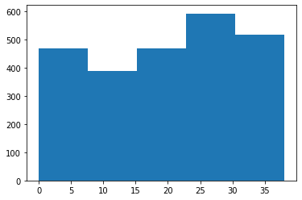

```python
#### Plotting the histogram of the class distribution
import matplotlib.pyplot as plt
plt.hist(pcaMix[:,-1],bins=5)
print()
```

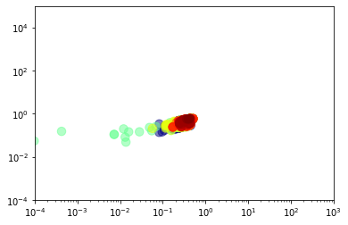

```python
#### Plotting part of the data
plt.scatter(pcaMix[:,0], pcaMix[:,5], c=pcaMix[:,-1],s=90, cmap="jet", alpha=0.5) # c for color, alpha for transparent points
plt.xlim(0.0001, 1000)
plt.ylim(0.0001, 100000)
plt.xscale('log')
plt.yscale('log')
plt.show()
```

### 3.5 CLUSTER DECOMPOSITION --KMEANS-- ON PCA FEATURES

```python
from sklearn.cluster import KMeans
km_PCA_target =[]
for i,c in enumerate(classdist):

    X = pcaMix[np.where(pcaMix[:,-1]==i)][:,:-1] # Find instances of the class
    y = np.zeros((c,1))+i
    nclusters = math.floor((c/Avg)+1) # Calculate number of clusters
    print('Clusters to decompose class '+str(i)+':', nclusters)
    z = tBaseCopy[i]
    if nclusters>1:
        kmeans = KMeans(n_clusters=nclusters).fit(X)
    ## add to the last column decimals for the new class
        for j,n in enumerate(X):
            y[j]=y[j]+(kmeans.labels_[j]/10) # divide by 10 so that it gets ,!added as decimal
        print('Decomposed version of class '+str(i)+':')
        print(z)
        print(np.concatenate((X,y),axis=1))
    if i==0: # If this is the first time, copy the first class into a new repo
        repo_decompPCA1 = np.concatenate((X,y),axis=1).copy()
        f2=y.copy()
        km_PCA_target.append(f2)
    else: # stack the new into the existing
        repo_decompPCA1 = np.vstack((repo_decompPCA1,np.concatenate((X,y),axis=1)))
        f2=y.copy()
        km_PCA_target.append(f2)
#print('Decomposed repo')
#print(repo_decompPCA1)
```

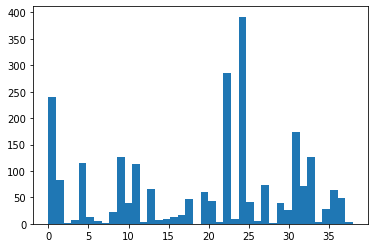

```python
#### Plotting the histogram of the new class distribution
plt.hist(repo_decompPCA1[:,-1],bins=40)
plt.show()
```

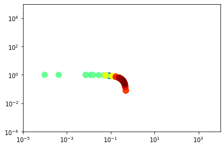

```python
#### Plotting the data
plt.scatter(repo_decompPCA1[:,0], repo_decompPCA1[:,1], c=repo_decompPCA1[:,-1],s=90, cmap="jet") # c for color, alpha for transparent points
plt.xlim(0.00001, 10000)
plt.ylim(0.0001, 100000)
plt.xscale('log')
plt.yscale('log')
plt.show()
```

```python
KMnamePCA = []
for i in range(len(km_PCA_target)):
    for j in range(len(km_PCA_target[i])):
        name = tBaseCopy[i] + '_' + str(km_PCA_target[i][j])
        KMnamePCA.append(name)
```

```python
KMnamePCACopy = KMnamePCA.copy()
KMnPCACopy, indKMnamePCACopy = np.unique(KMnamePCACopy, return_inverse=True)
print(len(KMnPCACopy))
print(len(indKMnamePCACopy))
print(indKMnamePCACopy[345:356])
```

```
65
2432
[9 9 9 9 9 9 9 9 9 9 9]
```

We see here that 65 classes are created in total out of the initial 39.

```python
import pandas as pd
#data_BinC = data_Bin.copy()
df5 = pd.DataFrame(columns = ['pcaKM', 'new_target', 'new_target_INT','new_target_name'])
for i in range(len(indKMnamePCACopy)):
    df5 = df5.append({'pcaKM': repo_decompPCA1[i,:-1], 'new_target': repo_decompPCA1[i,-1],'new_target_INT':indKMnamePCACopy[i], 'new_target_name':KMnamePCACopy[i]},ignore_index=True)
```

```python
df5[200:210]
```

|  | pcaKM | new_target | new_target_INT | new_target_name |
| --- | --- | --- | --- | --- |
| 200 | [0.25178880000000015, 0.5905654720895576, 0.0,... | 0.2 | 3 | Arrowhead_[0.2] |
| 201 | [0.2255296000000001, 0.635755551167, 0.0, 0.0,... | 0.2 | 3 | Arrowhead_[0.2] |
| 202 | [0.17007415999999997, 0.729819908040527, 0.0, ... | 0.2 | 3 | Arrowhead_[0.2] |
| 203 | [0.244016, 0.6035017946543942, 0.0, 0.0, 1.110... | 0.0 | 5 | Arrowhead_[0.] |
| 204 | [0.23956776000000002, 0.6128096497717629, 0.0,... | 0.2 | 3 | Arrowhead_[0.2] |
| 205 | [0.25178880000000015, 0.5905654720895576, 0.0,... | 0.2 | 3 | Arrowhead_[0.2] |
| 206 | [0.2255296000000001, 0.635755551167, 0.0, 0.0,... | 0.2 | 3 | Arrowhead_[0.2] |
| 207 | [0.27304032, 0.5526243072920847, 0.0, 0.0, 1.1... | 0.0 | 5 | Arrowhead_[0.] |
| 208 | [0.2255296000000001, 0.635755551167, 0.0, 0.0,... | 0.2 | 3 | Arrowhead_[0.2] |
| 209 | [0.2700786399999999, 0.5596227753469816, 0.0, ... | 0.2 | 3 | Arrowhead_[0.2] |

Here we see a brief presentation of a random part of the created decomposed dataset which includes the extracted features, the new sublasses, their assignment to new classes for the purpose of later on augmentation and classification as well as the original class in text with the sublclass notification at the end.

### 3.6 CLUSTER DECOMPOSITION --Rule of thump with Agglomerative Clustering-- ON PCA FEATURES

```python
from sklearn.cluster import AgglomerativeClustering
import math
np.random.seed(100)
AGC_PCA_target =[]
for i,c in enumerate(classdist):

    X = pcaMix[np.where(pcaMix[:,-1]==i)][:,:-1] # Find instances of the class
    y = np.zeros((c,1))+i
    nclusters = math.floor((math.sqrt(len(pcaMix[np.where(pcaMix[:,-1]==i)][:,:])/2)+1)) # Calculate number of clusters with Rule of thumb
    print('Clusters to decompose class '+str(i)+':', nclusters)
    z = tBaseCopy[i]
    if nclusters>1:
        AGC = AgglomerativeClustering(n_clusters = nclusters, affinity='euclidean', linkage='ward')
        #AGC = KMeans(n_clusters=nclusters).fit(X)
        AGC.fit_predict(X)
    ## add to the last column decimals for the new class
        for j,n in enumerate(X):
            y[j]=y[j]+(AGC.labels_[j]/10) # divide by 10 so that it gets ,!added as decimal
        print('Decomposed version of class '+str(i)+':')
        print(z)
        print(np.concatenate((X,y),axis=1))
    if i==0: # If this is the first time, copy the first class into a new repo
        repo_decompPCA2 = np.concatenate((X,y),axis=1).copy()
        f=y.copy()
        AGC_PCA_target.append(f)
    else: # stack the new into the existing
        repo_decompPCA2 = np.vstack((repo_decompPCA2,np.concatenate((X,y),axis=1)))
        f=y.copy()
        AGC_PCA_target.append(f)
#print('Decomposed repo')
#print(repo_decompPCA2)
```

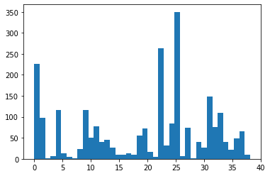

```python
#### Plotting the histogram of the new class distribution
plt.hist(repo_decompPCA2[:,-1],bins=40)
plt.show()
```

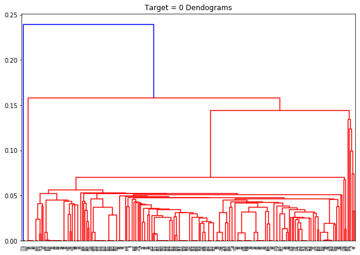

```python
#### Dendrogram of cluster 0
import scipy.cluster.hierarchy as shc
Z = pcaMix[np.where(pcaMix[:,-1]==0)][:,:-1]
plt.figure(figsize=(10, 7))
plt.title("Target = 0 Dendograms")
dend = shc.dendrogram(shc.linkage(Z, method='single'))
```

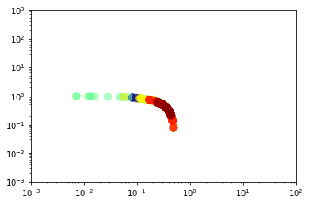

```python
#### Plotting part of the data
plt.scatter(repo_decompPCA2[:,0], repo_decompPCA2[:,1], c=repo_decompPCA2[:,-1], s=90, cmap="jet", alpha=0.5) # c for color, alpha for transparent points
plt.xlim(0.001, 100)
plt.ylim(0.001, 1000)
plt.xscale('log')
plt.yscale('log')
plt.show()
```

```python
AGCnamePCA = []
for i in range(len(AGC_PCA_target)):
    for j in range(len(AGC_PCA_target[i])):
        name = tBaseCopy[i] + '_' + str(AGC_PCA_target[i][j])
        AGCnamePCA.append(name)
```

```python
AGCnamePCACopy = AGCnamePCA.copy()
AGCnPCACopy, indAGCnamePCACopy = np.unique(AGCnamePCACopy, return_inverse=True)
print("number of new clusters: ", len(AGCnPCACopy))
print("number of pictures: ", len(indAGCnamePCACopy))
print("class depiction of random features: ", indAGCnamePCACopy[100:126])
```

```
number of new clusters:  195
number of pictures:  2432
class depiction of random features:  [13 16  9 16  8 16 16 16 16 16 16 16 17 16 16 16  9 16 10 10 16 16 16  8
 11 16]
```

We see here that 195 classes are created out of the initial 39

```python
import pandas as pd

df6 = pd.DataFrame(columns = ['pcaAGC', 'new_target', 'new_target_INT','new_target_name'])
for i in range(len(indAGCnamePCACopy)):
    df6 = df6.append({'pcaAGC': repo_decompPCA2[i,:-1], 'new_target': repo_decompPCA2[i,-1],'new_target_INT':indAGCnamePCACopy[i], 'new_target_name':AGCnamePCACopy[i]},ignore_index=True)
```

```python
df6[100:120]
```

|  | pcaAGC | new_target | new_target_INT | new_target_name |
| --- | --- | --- | --- | --- |
| 100 | [0.244016, 0.6035017946543942, 0.0, 0.0, 1.110... | 0.7 | 13 | Arrowhead_[0.7] |
| 101 | [0.28966391999999996, 0.5237175380239139, 0.0,... | 0.0 | 16 | Arrowhead_[0.] |
| 102 | [0.2762558399999999, 0.5480224631328997, 0.0, ... | 0.3 | 9 | Arrowhead_[0.3] |
| 103 | [0.30246784000000004, 0.4991877763744607, 0.0,... | 0.0 | 16 | Arrowhead_[0.] |
| 104 | [0.2512284, 0.5924687217149802, 0.0, 0.0, 1.11... | 0.2 | 8 | Arrowhead_[0.2] |
| 105 | [0.3040043200000001, 0.4973180963965745, 0.0, ... | 0.0 | 16 | Arrowhead_[0.] |
| 106 | [0.3021601600000001, 0.5006086756588802, 0.0, ... | 0.0 | 16 | Arrowhead_[0.] |
| 107 | [0.2721664800000001, 0.5541219383025253, 0.0, ... | 0.0 | 16 | Arrowhead_[0.] |
| 108 | [0.30492856, 0.4956656415375989, 0.0, 0.0, 1.1... | 0.0 | 16 | Arrowhead_[0.] |
| 109 | [0.3021608800000002, 0.4997348847234972, 0.0, ... | 0.0 | 16 | Arrowhead_[0.] |
| 110 | [0.3021608800000002, 0.4997348847234972, 0.0, ... | 0.0 | 16 | Arrowhead_[0.] |
| 111 | [0.27304032, 0.5526243072920847, 0.0, 0.0, 1.1... | 0.0 | 16 | Arrowhead_[0.] |
| 112 | [0.2501107199999999, 0.5949085154874567, 0.0, ... | 1.0 | 17 | Arrowhead_[1.] |
| 113 | [0.3043129600000001, 0.495894019820647, 0.0, 0... | 0.0 | 16 | Arrowhead_[0.] |
| 114 | [0.3040043200000001, 0.4973180963965745, 0.0, ... | 0.0 | 16 | Arrowhead_[0.] |
| 115 | [0.3040043200000001, 0.4973180963965745, 0.0, ... | 0.0 | 16 | Arrowhead_[0.] |
| 116 | [0.27508328000000004, 0.5505669052881254, 0.0,... | 0.3 | 9 | Arrowhead_[0.3] |
| 117 | [0.3058536800000001, 0.494479621969438, 0.0, 0... | 0.0 | 16 | Arrowhead_[0.] |
| 118 | [0.37297559999999996, 0.3621843498008239, 0.0,... | 0.4 | 10 | Arrowhead_[0.4] |
| 119 | [0.38748247999999996, 0.33161590653824025, 0.0... | 0.4 | 10 | Arrowhead_[0.4] |

Here we see a brief presentation of a random part of the created decomposed dataset which includes the extracted features, the new sublasses, their assignment to new classes for the purpose of later on augmentation and classification as well as the original class in text with the sublclass notification at the end.

## 4. IMAGE AUGMENTATION

The original image repository created was used to draw images for the data augmentation process. Two new image repositories were created:

For the first: Skimage was used and the images were rescaled, rotated by 45 degrees, colour inverted, randomly blurred with noise. This way out of the original image 3 new images were created, thus expanding our original dataset.

For the second: Two more image alterations were added. This second image repository can be found towards the end of this notebook right before the last CNN is implemented.

```python
#### import packages
from skimage.filters import median
from skimage.filters import sobel_h
from skimage.util import random_noise
from skimage.transform import rescale
from skimage.color import rgb2gray
from skimage import util
from skimage.transform import rotate
from skimage import exposure
from scipy import ndimage
import warnings
warnings.filterwarnings("ignore")
```

Below the images are resized, with the original yet resized image kept in the dataset followed by 3 augmented images of itself through the following three techniques: 45 degrees rotation, color inversion, add random noise.

```python
#### augment and store images in greyscale from each directory
targetBase2 = []
imgData2 = []
for path in listOfDirs:
    data_path = get_imlist(path)
    for i in data_path:
        files = glob.glob(i)
        x = pathlib.PurePath(i)
        y = x.parent.name
        targetBase2.append(y)
        targetBase2.append(y)
        targetBase2.append(y)
        targetBase2.append(y)
        for f1 in files:
            img = cv2.imread(f1, 0)
            img1 = cv2.resize(img, (100,100)) #image resize
            img2 = rotate(img1, 45) #image 45 degrees rotation
            img3 = util.invert(img1) #color inversion
            img4 = random_noise(img1)# add random noise
            imgData2.append(img1)
            imgData2.append(img2)
            imgData2.append(img3)
            imgData2.append(img4)
```

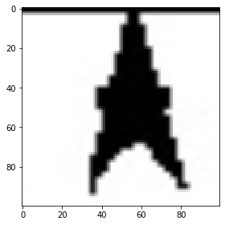

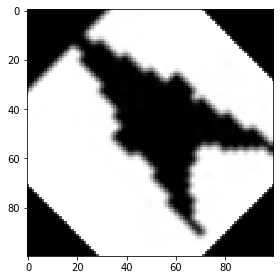

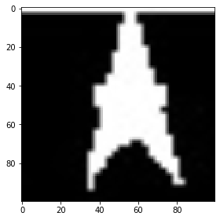

[figure not shown]

```python
#### proof of image transformation over the first image
from skimage import io
io.imshow(imgData2[0])
io.show()
io.imshow(imgData2[1])
io.show()
io.imshow(imgData2[2])
io.show()
io.imshow(imgData2[3])
io.show()
```

Here we see the proof of the image augmentation that took place over a certain class with the original resized image as well as the three new images that came out of it according to certain augmentation techniques.

```python
#### proof of image augmentation
print(len(imgData2))
print(imgData2[0].shape)
print()
print(len(targetBase2))
print(targetBase2[4000])
```

```
9728
(100, 100)

9728
Injector Point
```

## 5. DATA AUGMETNATION

### 5.1 augmentation on HOG data

```python
from collections import Counter # doctest: +SKIP
from imblearn.under_sampling import CondensedNearestNeighbour

cnn = CondensedNearestNeighbour(sampling_strategy='majority', random_state=42) # doctest: +SKIP
X_res, y_res = cnn.fit_resample(hogMix[:,:-1],hogMix[:,-1]) #doctest: +SKIP
print('Resampled dataset shape %s' % Counter(y_res)) # doctest: +SKIP

cnn = CondensedNearestNeighbour(sampling_strategy='majority', random_state=42) # doctest: +SKIP
X_res2, y_res2 = cnn.fit_resample(X_res, y_res) #doctest: +SKIP
print('Resampled dataset shape %s' % Counter(y_res2))

cnn = CondensedNearestNeighbour(sampling_strategy='majority', random_state=42) # doctest: +SKIP
X_res3, y_res3 = cnn.fit_resample(X_res2, y_res2) #doctest: +SKIP
print('Resampled dataset shape %s' % Counter(y_res3))

cnn = CondensedNearestNeighbour(sampling_strategy='majority', random_state=42) # doctest: +SKIP
X_res4, y_res4 = cnn.fit_resample(X_res3, y_res3) #doctest: +SKIP
print('Resampled dataset shape %s' % Counter(y_res4))

cnn = CondensedNearestNeighbour(sampling_strategy='majority', random_state=42) # doctest: +SKIP
X_res5, y_res5 = cnn.fit_resample(X_res4, y_res4) #doctest: +SKIP
print('Resampled dataset shape %s' % Counter(y_res5))

cnn = CondensedNearestNeighbour(sampling_strategy='majority', random_state=42) # doctest: +SKIP
X_res6, y_res6 = cnn.fit_resample(X_res5, y_res5) #doctest: +SKIP
print('Resampled dataset shape %s' % Counter(y_res6))

cnn = CondensedNearestNeighbour(sampling_strategy='majority', random_state=42) # doctest: +SKIP
X_res7, y_res7 = cnn.fit_resample(X_res6, y_res6) #doctest: +SKIP
print('Resampled dataset shape %s' % Counter(y_res7))

from imblearn.over_sampling import RandomOverSampler
ros = RandomOverSampler(random_state=0)
HOGrepo_ros, HOGtarget_ros = ros.fit_resample(X_res7, y_res7)
```

```python
#### proof of augmentation

print("original sample : ", len(hogMix))
print("multiple undersampling : ")
print(len(X_res))
print(len(X_res2))
print(len(X_res3))
print(len(X_res4))
print(len(X_res5))
print(len(X_res6))
print(len(X_res7))
print("final sample : ",len(HOGrepo_ros))
```

```
original sample :  2432
multiple undersampling :
2041
1759
1522
1354
1231
1110
995
final sample :  4407
```

```python
histo = [['Class','Number of Samples']]
for i, label1 in enumerate(sorted(list(set(HOGtarget_ros)))):
    cont = 0
    for j, label2 in enumerate(HOGtarget_ros):
        if label1 == label2:
            cont+=1
    histo.append([label1,cont])
histo.append(['Total Samples', len(HOGtarget_ros)])
```

```
    Class  Number of Samples
0     0.0                113
1     1.0                113
2     2.0                113
3     3.0                113
4     4.0                113
5     5.0                113
6     6.0                113
7     7.0                113
8     8.0                113
9     9.0                113
10   10.0                113
11   11.0                113
12   12.0                113
13   13.0                113
```

[output cut: 26 more lines]

[figure not shown]

```python
####  proof of augmentation 2-Convert histo into a panda dataframe
import seaborn as sns
histo_panda = pd.DataFrame.from_records(histo[1:-1], columns=histo[0])
print(histo_panda)
print('Total of symbols: '+str(len(HOGtarget_ros)))
## Create a histogram using seaborn
sns_plot = sns.barplot(y="Number of Samples", x="Class", data=histo_panda)
## Save the image
#sns_plot.figure.set_size_inches(24, 24)
#sns_plot.figure.savefig(path+'_barchart_ros'+'.jpg', orientation = 'landscape', dpi = 600)
#print('\nShowing class distribution bar chart (after ros)...')
plt.show()
```

We can clearly see that all classes have the same number of image extracted features.

### 5.2 Augmentation on PCA data

```python
from collections import Counter # doctest: +SKIP
from imblearn.under_sampling import CondensedNearestNeighbour

cnn = CondensedNearestNeighbour(sampling_strategy='majority', random_state=42) # doctest: +SKIP
PCA_X_res, PCA_y_res = cnn.fit_resample(pcaMix[:,:-1],pcaMix[:,-1]) #doctest: +SKIP
print('Resampled dataset shape %s' % Counter(PCA_y_res)) # doctest: +SKIP

cnn = CondensedNearestNeighbour(sampling_strategy='majority', random_state=42) # doctest: +SKIP
PCA_X_res2, PCA_y_res2 = cnn.fit_resample(PCA_X_res, PCA_y_res) #doctest: +SKIP
print('Resampled dataset shape %s' % Counter(PCA_y_res2))

cnn = CondensedNearestNeighbour(sampling_strategy='majority', random_state=42) # doctest: +SKIP
PCA_X_res3, PCA_y_res3 = cnn.fit_resample(PCA_X_res2, PCA_y_res2) #doctest: +SKIP
print('Resampled dataset shape %s' % Counter(PCA_y_res3))

cnn = CondensedNearestNeighbour(sampling_strategy='majority', random_state=42) # doctest: +SKIP
PCA_X_res4, PCA_y_res4 = cnn.fit_resample(PCA_X_res3, PCA_y_res3) #doctest: +SKIP
print('Resampled dataset shape %s' % Counter(PCA_y_res4))

cnn = CondensedNearestNeighbour(sampling_strategy='majority', random_state=42) # doctest: +SKIP
PCA_X_res5, PCA_y_res5 = cnn.fit_resample(PCA_X_res4, PCA_y_res4) #doctest: +SKIP
print('Resampled dataset shape %s' % Counter(PCA_y_res5))

cnn = CondensedNearestNeighbour(sampling_strategy='majority', random_state=42) # doctest: +SKIP
PCA_X_res6, PCA_y_res6 = cnn.fit_resample(PCA_X_res5, PCA_y_res5) #doctest: +SKIP
print('Resampled dataset shape %s' % Counter(PCA_y_res6))

cnn = CondensedNearestNeighbour(sampling_strategy='majority', random_state=42) # doctest: +SKIP
PCA_X_res7, PCA_y_res7 = cnn.fit_resample(PCA_X_res6, PCA_y_res6) #doctest: +SKIP
print('Resampled dataset shape %s' % Counter(PCA_y_res7))

from imblearn.over_sampling import RandomOverSampler
ros = RandomOverSampler(random_state=0)
PCA_repo_ros, PCA_target_ros = ros.fit_resample(PCA_X_res7, PCA_y_res7)
```

```python
#### proof of augmentation
print("original sample : ", len(pcaMix))
print("multiple undersampling : ")
print(len(PCA_X_res))
print(len(PCA_X_res2))
print(len(PCA_X_res3))
print(len(PCA_X_res4))
print(len(PCA_X_res5))
print(len(PCA_X_res6))
print(len(PCA_X_res7))
print("final sample : ",len(PCA_repo_ros))
```

```
original sample :  2432
multiple undersampling :
2046
1769
1537
1372
1254
1134
1022
final sample :  4407
```

```python
histo = [['Class','Number of Samples']]
for i, label1 in enumerate(sorted(list(set(PCA_target_ros)))):
    cont = 0
    for j, label2 in enumerate(PCA_target_ros):
        if label1 == label2:
            cont+=1
    histo.append([label1,cont])
histo.append(['Total Samples', len(PCA_target_ros)])
```

```
    Class  Number of Samples
0     0.0                113
1     1.0                113
2     2.0                113
3     3.0                113
4     4.0                113
5     5.0                113
6     6.0                113
7     7.0                113
8     8.0                113
9     9.0                113
10   10.0                113
11   11.0                113
12   12.0                113
13   13.0                113
```

[output cut: 26 more lines]

[figure not shown]

```python
####  proof of augmentation 2-Convert histo into a panda dataframe

import seaborn as sns
histo_panda = pd.DataFrame.from_records(histo[1:-1], columns=histo[0])
print(histo_panda)
print('Total of symbols: '+str(len(PCA_target_ros)))
## Create a histogram using seaborn
sns_plot = sns.barplot(y="Number of Samples", x="Class", data=histo_panda)
## Save the image
#sns_plot.figure.set_size_inches(24, 24)
#sns_plot.figure.savefig(path+'_barchart_ros'+'.jpg', orientation = 'landscape', dpi = 600)
#print('\nShowing class distribution bar chart (after ros)...')
plt.show()
```

We can clearly see that all classes have the same number of image extracted features.

### 5.3 Augmentation on k-means decomposed HOG data

```python
# augmentation on k-means decomposed HOG data

from collections import Counter # doctest: +SKIP
from imblearn.under_sampling import CondensedNearestNeighbour

cnn = CondensedNearestNeighbour(sampling_strategy='majority', random_state=42) # doctest: +SKIP
X_res, y_res = cnn.fit_resample(repo_decompHOG[:,:-1],indnctHOG) #doctest: +SKIP
print('Resampled dataset shape %s' % Counter(y_res)) # doctest: +SKIP

cnn = CondensedNearestNeighbour(sampling_strategy='majority', random_state=42) # doctest: +SKIP
X_res2, y_res2 = cnn.fit_resample(X_res, y_res) #doctest: +SKIP
print('Resampled dataset shape %s' % Counter(y_res2))

cnn = CondensedNearestNeighbour(sampling_strategy='majority', random_state=42) # doctest: +SKIP
X_res3, y_res3 = cnn.fit_resample(X_res2, y_res2) #doctest: +SKIP
print('Resampled dataset shape %s' % Counter(y_res3))

cnn = CondensedNearestNeighbour(sampling_strategy='majority', random_state=42) # doctest: +SKIP
X_res4, y_res4 = cnn.fit_resample(X_res3, y_res3) #doctest: +SKIP
print('Resampled dataset shape %s' % Counter(y_res4))

cnn = CondensedNearestNeighbour(sampling_strategy='majority', random_state=42) # doctest: +SKIP
X_res5, y_res5 = cnn.fit_resample(X_res4, y_res4) #doctest: +SKIP
print('Resampled dataset shape %s' % Counter(y_res5))

cnn = CondensedNearestNeighbour(sampling_strategy='majority', random_state=42) # doctest: +SKIP
X_res6, y_res6 = cnn.fit_resample(X_res5, y_res5) #doctest: +SKIP
print('Resampled dataset shape %s' % Counter(y_res6))

cnn = CondensedNearestNeighbour(sampling_strategy='majority', random_state=42) # doctest: +SKIP
X_res7, y_res7 = cnn.fit_resample(X_res6, y_res6) #doctest: +SKIP
print('Resampled dataset shape %s' % Counter(y_res7))

from imblearn.over_sampling import RandomOverSampler
ros = RandomOverSampler(random_state=0)
decHOGrepo_ros, decHOGtarget_ros = ros.fit_resample(X_res7, y_res7)
```

```python
print("original sample : ", len(repo_decompHOG))
print("multiple undersampling : ")
print(len(X_res))
print(len(X_res2))
print(len(X_res3))
print(len(X_res4))
print(len(X_res5))
print(len(X_res6))
print(len(X_res7))
print("final sample : ",len(decHOGrepo_ros))
```

```
original sample :  2432
multiple undersampling :
2335
2248
2174
2098
2024
1949
1881
final sample :  4355
```

```python
histo = [['Class','Number of Samples']]
for i, label1 in enumerate(sorted(list(set(decHOGtarget_ros)))):
    cont = 0
    for j, label2 in enumerate(decHOGtarget_ros):
        if label1 == label2:
            cont+=1
    histo.append([label1,cont])
histo.append(['Total Samples', len(decHOGtarget_ros)])
```

```
    Class  Number of Samples
0       0                 67
1       1                 67
2       2                 67
3       3                 67
4       4                 67
5       5                 67
6       6                 67
7       7                 67
8       8                 67
9       9                 67
10     10                 67
11     11                 67
12     12                 67
13     13                 67
```

[output cut: 50 more lines]

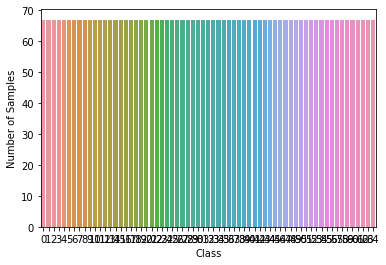

```python
#  proof of augmentation 2
import seaborn as sns
## Convert histo into a panda dataframe
histo_panda = pd.DataFrame.from_records(histo[1:-1], columns=histo[0])
print(histo_panda)
print('Total of symbols: '+str(len(decHOGtarget_ros)))
## Create a histogram using seaborn
sns_plot = sns.barplot(y="Number of Samples", x="Class", data=histo_panda)
## Save the image
#sns_plot.figure.set_size_inches(24, 24)
#sns_plot.figure.savefig(path+'_barchart_ros'+'.jpg', orientation = 'landscape', dpi = 600)
#print('\nShowing class distribution bar chart (after ros)...')
plt.show()
```

We can clearly see that all classes have the same number of image extracted features.

### 5.4 Augmentation on agglomerative clustering decomposed HOG data

```python
# augmentation on agglomerative clustering desomposed HOG data

from collections import Counter # doctest: +SKIP
from imblearn.under_sampling import CondensedNearestNeighbour

cnn = CondensedNearestNeighbour(sampling_strategy='majority', random_state=42) # doctest: +SKIP
X_res, y_res = cnn.fit_resample(repo_decompAGC[:,:-1],indAGCnHOG) #doctest: +SKIP
print('Resampled dataset shape %s' % Counter(y_res)) # doctest: +SKIP

cnn = CondensedNearestNeighbour(sampling_strategy='majority', random_state=42) # doctest: +SKIP
X_res2, y_res2 = cnn.fit_resample(X_res, y_res) #doctest: +SKIP
print('Resampled dataset shape %s' % Counter(y_res2))

cnn = CondensedNearestNeighbour(sampling_strategy='majority', random_state=42) # doctest: +SKIP
X_res3, y_res3 = cnn.fit_resample(X_res2, y_res2) #doctest: +SKIP
print('Resampled dataset shape %s' % Counter(y_res3))

cnn = CondensedNearestNeighbour(sampling_strategy='majority', random_state=42) # doctest: +SKIP
X_res4, y_res4 = cnn.fit_resample(X_res3, y_res3) #doctest: +SKIP
print('Resampled dataset shape %s' % Counter(y_res4))

cnn = CondensedNearestNeighbour(sampling_strategy='majority', random_state=42) # doctest: +SKIP
X_res5, y_res5 = cnn.fit_resample(X_res4, y_res4) #doctest: +SKIP
print('Resampled dataset shape %s' % Counter(y_res5))

cnn = CondensedNearestNeighbour(sampling_strategy='majority', random_state=42) # doctest: +SKIP
X_res6, y_res6 = cnn.fit_resample(X_res5, y_res5) #doctest: +SKIP
print('Resampled dataset shape %s' % Counter(y_res6))

cnn = CondensedNearestNeighbour(sampling_strategy='majority', random_state=42) # doctest: +SKIP
X_res7, y_res7 = cnn.fit_resample(X_res6, y_res6) #doctest: +SKIP
print('Resampled dataset shape %s' % Counter(y_res7))

from imblearn.over_sampling import RandomOverSampler
ros = RandomOverSampler(random_state=0)
decAGGHOGrepo_ros, decAGGHOGtarget_ros = ros.fit_resample(X_res7, y_res7)
```

```python
print("original sample : ", len(decAGGHOGrepo_ros))
print("multiple undersampling : ")
print(len(X_res))
print(len(X_res2))
print(len(X_res3))
print(len(X_res4))
print(len(X_res5))
print(len(X_res6))
print(len(X_res7))
print("final sample : ",len(decAGGHOGrepo_ros))
```

```
original sample :  7410
multiple undersampling :
2384
2337
2293
2250
2209
2168
2128
final sample :  7410
```

```python
histo = [['Class','Number of Samples']]
for i, label1 in enumerate(sorted(list(set(decAGGHOGtarget_ros)))):
    cont = 0
    for j, label2 in enumerate(decAGGHOGtarget_ros):
        if label1 == label2:
            cont+=1
    histo.append([label1,cont])
histo.append(['Total Samples', len(decAGGHOGtarget_ros)])
```

```python
#  proof of augmentation 2
import seaborn as sns
## Convert histo into a panda dataframe
histo_panda = pd.DataFrame.from_records(histo[1:-1], columns=histo[0])
print(histo_panda)
print('Total of symbols: '+str(len(decAGGHOGtarget_ros)))
## Create a histogram using seaborn
sns_plot = sns.barplot(y="Number of Samples", x="Class", data=histo_panda)
## Save the image
#sns_plot.figure.set_size_inches(24, 24)
#sns_plot.figure.savefig(path+'_barchart_ros'+'.jpg', orientation = 'landscape', dpi = 600)
#print('\nShowing class distribution bar chart (after ros)...')
plt.show()
```

[output not shown]

### 5.5 Augmentation on k-means decomposed PCA data

```python
# augmentation on HOG data

from collections import Counter # doctest: +SKIP
from imblearn.under_sampling import CondensedNearestNeighbour

cnn = CondensedNearestNeighbour(sampling_strategy='majority', random_state=42) # doctest: +SKIP
X_res, y_res = cnn.fit_resample(repo_decompPCA1[:,:-1],indKMnamePCACopy) #doctest: +SKIP
print('Resampled dataset shape %s' % Counter(y_res)) # doctest: +SKIP

cnn = CondensedNearestNeighbour(sampling_strategy='majority', random_state=42) # doctest: +SKIP
X_res2, y_res2 = cnn.fit_resample(X_res, y_res) #doctest: +SKIP
print('Resampled dataset shape %s' % Counter(y_res2))

cnn = CondensedNearestNeighbour(sampling_strategy='majority', random_state=42) # doctest: +SKIP
X_res3, y_res3 = cnn.fit_resample(X_res2, y_res2) #doctest: +SKIP
print('Resampled dataset shape %s' % Counter(y_res3))

cnn = CondensedNearestNeighbour(sampling_strategy='majority', random_state=42) # doctest: +SKIP
X_res4, y_res4 = cnn.fit_resample(X_res3, y_res3) #doctest: +SKIP
print('Resampled dataset shape %s' % Counter(y_res4))

cnn = CondensedNearestNeighbour(sampling_strategy='majority', random_state=42) # doctest: +SKIP
X_res5, y_res5 = cnn.fit_resample(X_res4, y_res4) #doctest: +SKIP
print('Resampled dataset shape %s' % Counter(y_res5))

cnn = CondensedNearestNeighbour(sampling_strategy='majority', random_state=42) # doctest: +SKIP
X_res6, y_res6 = cnn.fit_resample(X_res5, y_res5) #doctest: +SKIP
print('Resampled dataset shape %s' % Counter(y_res6))

cnn = CondensedNearestNeighbour(sampling_strategy='majority', random_state=42) # doctest: +SKIP
X_res7, y_res7 = cnn.fit_resample(X_res6, y_res6) #doctest: +SKIP
print('Resampled dataset shape %s' % Counter(y_res7))

from imblearn.over_sampling import RandomOverSampler
ros = RandomOverSampler(random_state=0)
decPCArepo_ros, decPCAtarget_ros = ros.fit_resample(X_res7, y_res7)
```

```python
print("original sample : ", len(indKMnamePCACopy))
print("multiple undersampling : ")
print(len(X_res))
print(len(X_res2))
print(len(X_res3))
print(len(X_res4))
print(len(X_res5))
print(len(X_res6))
print(len(X_res7))
print("final sample : ",len(decPCAtarget_ros))
```

```
original sample :  2432
multiple undersampling :
2177
2041
1932
1832
1738
1645
1557
final sample :  4745
```

```python
histo = [['Class','Number of Samples']]
for i, label1 in enumerate(sorted(list(set(decPCAtarget_ros)))):
    cont = 0
    for j, label2 in enumerate(decPCAtarget_ros):
        if label1 == label2:
            cont+=1
    histo.append([label1,cont])
histo.append(['Total Samples', len(decPCAtarget_ros)])
```

```
    Class  Number of Samples
0       0                 73
1       1                 73
2       2                 73
3       3                 73
4       4                 73
5       5                 73
6       6                 73
7       7                 73
8       8                 73
9       9                 73
10     10                 73
11     11                 73
12     12                 73
13     13                 73
```

[output cut: 50 more lines]

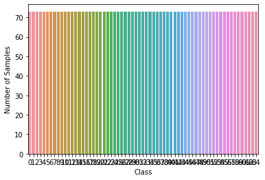

```python
#  proof of augmentation 2
import seaborn as sns
## Convert histo into a panda dataframe
histo_panda = pd.DataFrame.from_records(histo[1:-1], columns=histo[0])
print(histo_panda)
print('Total of symbols: '+str(len(decPCAtarget_ros)))
## Create a histogram using seaborn
sns_plot = sns.barplot(y="Number of Samples", x="Class", data=histo_panda)
## Save the image
#sns_plot.figure.set_size_inches(24, 24)
#sns_plot.figure.savefig(path+'_barchart_ros'+'.jpg', orientation = 'landscape', dpi = 600)
#print('\nShowing class distribution bar chart (after ros)...')
plt.show()
```

We can clearly see that all classes have the same number of image extracted features.

### 5.6 Augmentation on agglomerative clustering decomposed PCA data

```python
# augmentation on PCA agglomerative clustering decomposed data

from collections import Counter # doctest: +SKIP
from imblearn.under_sampling import CondensedNearestNeighbour
from imblearn.under_sampling import OneSidedSelection

cnn = CondensedNearestNeighbour(sampling_strategy='majority', random_state=42) # doctest: +SKIP
X_res, y_res = cnn.fit_resample(repo_decompPCA2[:,:-1],indAGCnamePCACopy) #doctest: +SKIP
print('Resampled dataset shape %s' % Counter(y_res)) # doctest: +SKIP

cnn = CondensedNearestNeighbour(sampling_strategy='majority', random_state=42) # doctest: +SKIP
X_res2, y_res2 = cnn.fit_resample(X_res, y_res) #doctest: +SKIP
print('Resampled dataset shape %s' % Counter(y_res2))

cnn = CondensedNearestNeighbour(sampling_strategy='majority', random_state=42) # doctest: +SKIP
X_res3, y_res3 = cnn.fit_resample(X_res2, y_res2) #doctest: +SKIP
print('Resampled dataset shape %s' % Counter(y_res3))

cnn = CondensedNearestNeighbour(sampling_strategy='majority', random_state=42) # doctest: +SKIP
X_res4, y_res4 = cnn.fit_resample(X_res3, y_res3) #doctest: +SKIP
print('Resampled dataset shape %s' % Counter(y_res4))

cnn = CondensedNearestNeighbour(sampling_strategy='majority', random_state=42) # doctest: +SKIP
X_res5, y_res5 = cnn.fit_resample(X_res4, y_res4) #doctest: +SKIP
print('Resampled dataset shape %s' % Counter(y_res5))

cnn = CondensedNearestNeighbour(sampling_strategy='majority', random_state=42) # doctest: +SKIP
X_res6, y_res6 = cnn.fit_resample(X_res5, y_res5) #doctest: +SKIP
print('Resampled dataset shape %s' % Counter(y_res6))


oss = OneSidedSelection(sampling_strategy='majority',n_neighbors=2,n_seeds_S=2,random_state=42)
X_res7, y_res7 = oss.fit_resample(X_res6, y_res6)
print('Resampled dataset shape %s' % Counter(y_res7))

oss = OneSidedSelection(sampling_strategy='majority',n_neighbors=2,n_seeds_S=2,random_state=42)
X_res7, y_res7 = oss.fit_resample(X_res6, y_res6)
print('Resampled dataset shape %s' % Counter(y_res7))

from imblearn.over_sampling import RandomOverSampler
ros = RandomOverSampler(sampling_strategy='not majority', random_state=0)
AGCdecPCArepo_ros, AGCdecPCAtarget_ros = ros.fit_resample(X_res7, y_res7)
```

```python
print("original sample : ", len(AGCnamePCACopy))
print("multiple undersampling : ")
print(len(X_res))
print(len(X_res2))
print(len(X_res3))
print(len(X_res4))
print(len(X_res5))
print(len(X_res6))
print(len(X_res7))
print("final sample : ",len(AGCdecPCAtarget_ros))
```

```
original sample :  2432
multiple undersampling :
2183
2075
2019
1966
1913
1863
1814
final sample :  9360
```

```python
histo = [['Class','Number of Samples']]
for i, label1 in enumerate(sorted(list(set(AGCdecPCAtarget_ros)))):
    cont = 0
    for j, label2 in enumerate(AGCdecPCAtarget_ros):
        if label1 == label2:
            cont+=1
    histo.append([label1,cont])
histo.append(['Total Samples', len(AGCdecPCAtarget_ros)])
```

```
     Class  Number of Samples
0        0                 48
1        1                 48
2        2                 48
3        3                 48
4        4                 48
5        5                 48
6        6                 48
7        7                 48
8        8                 48
9        9                 48
10      10                 48
11      11                 48
12      12                 48
13      13                 48
```

[output cut: 50 more lines]

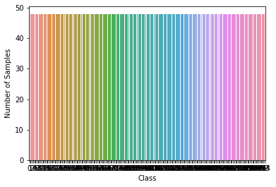

```python
# proof of augmentation
import seaborn as sns
## Convert histo into a panda dataframe
histo_panda = pd.DataFrame.from_records(histo[1:-1], columns=histo[0])
print(histo_panda)
print('Total of symbols: '+str(len(AGCdecPCAtarget_ros)))
## Create a histogram using seaborn
sns_plot = sns.barplot(y="Number of Samples", x="Class", data=histo_panda)
## Save the image
#sns_plot.figure.set_size_inches(24, 24)
#sns_plot.figure.savefig(path+'_barchart_ros'+'.jpg', orientation = 'landscape', dpi = 600)
#print('\nShowing class distribution bar chart (after ros)...')
plt.show()
```

We can clearly see that all classes have the same number of image extracted features.

Having created the datasets needed we go on to PART2, where classification algorithms are applied on these datasets.

# PART2

## 1. Introduction

#### Machine learning algorithms:

Support Vector Machine (SVM): a supervised machine learning algorithm which can be used for both classification or regression challenges. Here it is used for multiclass classification. In the SVM algorithm, we plot each data item as a point in n-dimensional space, with n being the number of features, with the value of each feature being the value of a particular coordinate. Then, classification is performed by finding the hyper-plane that differentiates the classes. Support Vectors are simply the co-ordinates of individual observation. For multiclass classification a one-versus-all approach is used for the creation of the hyper-plane for each class.

Random Forest: a versatile machine learning method capable of performing both regression and classification tasks. It is a type of ensemble learning method, where a group of weak models combine to form a powerful model. In Random Forest, multiple classification trees are grown. To classify a new object based on attributes, each tree gives a classification and the tree “votes” for that class. The forest chooses the classification having the most votes over all the trees in the forest.

Decision Trees: Decision tree classifier is a systematic approach for multiclass classification. It poses a set of questions to the dataset (related to its attributes/features). The decision tree classification algorithm can be visualized on a binary tree. On the root and each of the internal nodes, a question is posed and the data on that node is further split into separate records that have different characteristics. The leaves of the tree refer to the classes in which the dataset is split.

#### Parameter setting

SVM, Random Forest, Desicion Trees:

#### Neural Networks:

Artificial Neural Networks or ANN: A single perceptron (or neuron) can be imagined as a Logistic Regression. So ANN, is a group of multiple perceptrons/ neurons at each layer. ANN is capable of learning any nonlinear function. ANNs have the capacity to learn weights that map any input to the output. One of the main reasons behind universal approximation is the activation function. Activation functions introduce nonlinear properties to the network. This helps the network learn any complex relationship between input and output. One common problem in all these neural networks is the Vanishing and Exploding Gradient. This problem is associated with the backpropagation algorithm. The weights of a neural network are updated through this backpropagation algorithm by finding the gradients.

CNN: The building blocks of CNNs are filters a.k.a. kernels. Kernels are used to extract the relevant features from the input using the convolution operation. Convolving an image with filters results in a feature map. CNN learns the filters automatically without mentioning it explicitly. These filters help in extracting the right and relevant features from the input data. CNN captures the spatial features from an image. Spatial features refer to the arrangement of pixels and the relationship between them in an image. They help us in identifying the object accurately, the location of an object, as well as its relation with other objects in an image.

#### Parameter setting NN, CNN:

For both NN and CNN multiple activation functions, architectures and parameters were used. By obtaining results the best case was ultimately used. The activation functions tested were: “tanh”, “relu” and “sigmoid”, implemented for all architectures (different number of layers with different numbers of neurons).

For NN the optimizer used was “SGD”, stochastic gradient descent, while for CNN “SGD” and “Adam”.

For both NN and CNN the loss function was “sparse categorical crossentropy” which takes care of the multiclass problem by automatically performing one hot encoding, meaning that there is a binary feature for each class value and the predictions must have predicted probabilities for each of the classes. The cross-entropy is then summed across each binary feature and averaged across all examples in the dataset.

A table containing results for each model has been created. These results are the metrics for each model when model is applied on the test set, because this is what matters-how the model performs on unseen data.

## 2. MACHINE LEARNING CLASSIFICATION

The machine learning algorithms chosen were SVM, random forest and Decision trees. They were applied on the augmented both decomposed or not datasets of the extracted features of HOG and PCA processes. All datasets were split into training and test set. SVM run on the training set and then applied on the test set. Then cross-validation followed on the entire augmented dataset for all HOG and PCA augmented datasets. Cross validation is supposed to take random folds of the dataset and use them as training set then applying the trained model on the randomly selected for this instance test set. The number of folds was chosen to be 5. The same procedure was followed for random forest and Decision tree machine learning algorithm.

#### Metrics chosen:

Accuracy: the ratio of correctly predicted observation to the total observations.

Recall: the ratio of correctly predicted positive observations to the all observations in actual class

Precision: the ratio of correctly predicted positive observations to the total predicted positive observations. F1-score: the weighted average of Precision and Recall. Therefore, this score takes both false positives and false negatives into account.

Matthews correlation coefficient (MCC)/phi-coefficient (φ): The Matthews correlation coefficient is used in machine learning as a measure of the quality of binary and multiclass classifications. It takes into account true and false positives and negatives and is generally regarded as a balanced measure which can be used even if the classes are of very different sizes. The MCC is in essence a correlation coefficient value between -1 and +1. A coefficient of +1 represents a perfect prediction, 0 an average random prediction and -1 an inverse prediction. The statistic is also known as the phi coefficient.

Cohen’s kappa coefficient/kappa score: measures the degree of agreement between the true values and the predicted values, which we use as the classifier’s performance. 1 means perfect agreement and 0 is chance agreement.

For NN the same augmented datasets were used with the same training/test set split. This way NN can be compared regarding all metrics with previous models. Metric of loss is used too. CNN though is applied on the augmented image dataset which is also imbalanced. Therefore, we cannot compare CNN with the previous models even though the same way of trainset/test set split is applied. Metrics used for evaluating the model were the same as for NN.

### 2.1 Classification on HOG augmented dataset

### 2.1.1 SVM on HOG

```python
#### Training/test set split
from sklearn.model_selection import train_test_split
HOGX_train, HOGX_test, HOGy_train, HOGy_test = train_test_split(HOGrepo_ros, HOGtarget_ros,
                                                    stratify=HOGtarget_ros,
                                                    test_size=0.25, random_state = 40)
```

```python
#### train/test set split proof
print(len(HOGX_train)," ", HOGX_train.shape)
print(len(HOGX_test), " ", HOGX_test.shape)
print(len(HOGy_train), " ", HOGy_train.shape)
print(len(HOGy_test), " ", HOGy_test.shape)
```

```
3305   (3305, 4356)
1102   (1102, 4356)
3305   (3305,)
1102   (1102,)
```

```python
#### Use this cell to train a SVM model to predict the labels of the test data
from sklearn import svm
model_svm  = svm.SVC(gamma='auto', random_state=40)
HOGclf_svm = model_svm.fit(HOGX_train, HOGy_train)
HOGy_svm = HOGclf_svm.predict(HOGX_test)
```

```python
print(HOGy_svm,HOGy_svm.shape)
```

```
[29. 16. 16. ... 13. 17.  2.] (1102,)
```

```python
#### Metrics of svm model
import math
from sklearn.metrics import accuracy_score
HOGaccurSVM = accuracy_score(HOGy_test,HOGy_svm)
print('Accuracy of SVM: ', round(HOGaccurSVM,3))


from sklearn.metrics import recall_score
RecallSc = recall_score(HOGy_test,HOGy_svm, average='macro', zero_division=1)
print('Recall of SVM: ', round(RecallSc,3))

from sklearn.metrics import precision_score
HOGpresSVM = precision_score(HOGy_test,HOGy_svm, average='macro',zero_division=1)
print('Precision of SVM: ', round(HOGpresSVM,3))

from sklearn.metrics import f1_score
HOGF1_ScSVM = f1_score(HOGy_test,HOGy_svm, average='macro',zero_division=1)
print('F1_score: ', round(HOGF1_ScSVM,3))


from sklearn.metrics import confusion_matrix, cohen_kappa_score
HOGkapaSVM = cohen_kappa_score(HOGy_test, HOGy_svm)
print('kappa-score: ', round(HOGkapaSVM, 3))

from sklearn.metrics import matthews_corrcoef
HOG_MCC_SVM = matthews_corrcoef(HOGy_test, HOGy_svm)
print('MCC: ', round(HOG_MCC_SVM,3))
```

```
Accuracy of SVM:  0.811
Recall of SVM:  0.815
Precision of SVM:  0.891
F1_score:  0.779
kappa-score:  0.806
MCC:  0.81
```

```python
#### Cross validatig the original data (the function will do it all)
from sklearn.model_selection import cross_validate

scores_svm = cross_validate(model_svm, HOGrepo_ros, HOGtarget_ros, cv=5)
print('SVM cross-validated scores: ', scores_svm)
```

```
SVM cross-validated scores:  {'fit_time': array([96.99982405, 99.06001115, 97.36204362, 96.69233465, 97.03120375]), 'score_time': array([14.01310229, 14.76987839, 14.46829152, 14.11951137, 14.06685328]), 'test_score': array([0.73922902, 0.75623583, 0.71736663, 0.76276958, 0.77979569])}
```

```python
from sklearn.model_selection import cross_val_score
#### Evaluating Accuracy for each fold
HOGvalAccSVM = cross_val_score(model_svm, HOGrepo_ros, HOGtarget_ros, cv=5, scoring = 'accuracy')
print('Accuracy for SVM: ', HOGvalAccSVM)

#### Evaluating Mean Accuracy for all folds
print('Mean Accuracy for SVM: ',round(np.mean(HOGvalAccSVM),2))
```

```
Accuracy for SVM:  [0.73922902 0.75623583 0.71736663 0.76276958 0.77979569]
Mean Accuracy for SVM:  0.75
```

```python
#### Evaluating Precision, Recall and F1-score (both by fold and average)
HOGprecisionVal_SVM = cross_val_score(model_svm, HOGrepo_ros, HOGtarget_ros, cv=5, scoring = 'precision_macro')
MeanHOGprecisionVal_SVM = round(np.mean(HOGprecisionVal_SVM),2)


HOGrecallVal_SVM = cross_val_score(model_svm, HOGrepo_ros, HOGtarget_ros, cv=5, scoring = 'recall_macro')
MeanHOGrecallVal_SVM = round(np.mean(HOGrecallVal_SVM),2)

HOGF1Val_SVM = cross_val_score(model_svm, HOGrepo_ros, HOGtarget_ros, cv=5, scoring = 'f1_macro')
MeanHOGF1Val_SVM = round(np.mean(HOGF1Val_SVM),2)

print('Precision for SVM: ', HOGprecisionVal_SVM)
print('Mean Precision for SVM: ', MeanHOGprecisionVal_SVM)
print()
print('Recall for SVM: ', HOGrecallVal_SVM)
print('Mean Recall for SVM: ',MeanHOGrecallVal_SVM)
print()
print('F1-Score for SVM: ', HOGF1Val_SVM)
print('Mean F1-Score for SVM: ', MeanHOGF1Val_SVM)
```

```
Precision for SVM:  [0.81130149 0.78853995 0.78494799 0.79911015 0.7712069 ]
Mean Precision for SVM:  0.79

Recall for SVM:  [0.74227222 0.75894395 0.7210905  0.76608898 0.78296341]
Mean Recall for SVM:  0.75

F1-Score for SVM:  [0.71047785 0.73014669 0.68810073 0.73384068 0.75080058]
Mean F1-Score for SVM:  0.72
```

### 2.1.2 Random Forest on HOG

```python
#### Use this cell to train a RF model to predict the labels of the test data
from sklearn.ensemble import RandomForestClassifier
model_rf = RandomForestClassifier(n_estimators=10,random_state=0)
HOGclf_rf = model_rf.fit(HOGX_train, HOGy_train)
HOGy_rf = HOGclf_rf.predict(HOGX_test)
```

```python
#### Metrics for Random Forest
from sklearn.metrics import accuracy_score
HOGacc_rf = accuracy_score(HOGy_test,HOGy_rf)
print('Accuracy of RF: ', round(HOGacc_rf,3))

from sklearn.metrics import recall_score
HOGRecallSc_rf = recall_score(HOGy_test,HOGy_rf, average='macro')
print('Recall of RF: ', round(HOGRecallSc_rf,3))

from sklearn.metrics import precision_score
HOGpres_rf = precision_score(HOGy_test, HOGy_rf,average='macro')
print('Precision of RF: ', round(HOGpres_rf,3))

from sklearn.metrics import f1_score
HOGF1_Sc_rf = f1_score(HOGy_test,HOGy_rf, average='macro')
print('F1_score of RF: ', round(HOGF1_Sc_rf,3))

from sklearn.metrics import matthews_corrcoef
HOG_MCC_rf = matthews_corrcoef(HOGy_test, HOGy_rf)
print('MCC: ', round(HOG_MCC_rf,3))

from sklearn.metrics import confusion_matrix, cohen_kappa_score
HOGkapa_rf = cohen_kappa_score(HOGy_test, HOGy_rf)
print('kappa-score: ', round(HOGkapa_rf, 3))
```

```
Accuracy of RF:  0.989
Recall of RF:  0.989
Precision of RF:  0.989
F1_score of RF:  0.989
MCC:  0.989
kappa-score:  0.989
```

```python
#### Cross validatig the original data (the function will do it all)
HOGval_scores_rf = cross_validate(model_rf, HOGrepo_ros, HOGtarget_ros, cv=5)
print('RF cross-validated scores: ', HOGval_scores_rf)
```

```
RF cross-validated scores:  {'fit_time': array([1.16207361, 1.03445292, 1.05754304, 1.07008314, 1.21507955]), 'score_time': array([0.0156424 , 0.02098918, 0.03122306, 0.02098823, 0.01562524]), 'test_score': array([0.97165533, 0.97278912, 0.98524404, 0.98751419, 1.        ])}
```

```python
#### Evaluating Accuracy for each fold
HOGcrossValSccore_rf = cross_val_score(model_rf, HOGrepo_ros, HOGtarget_ros, cv=5, scoring = 'accuracy')
print('Accuracy for RF: ', HOGcrossValSccore_rf)
# Evaluating Mean Accuracy for all folds
print('Mean Accuracy for RF: ',round(np.mean(HOGcrossValSccore_rf),2))
```

```
Accuracy for RF:  [0.97165533 0.97278912 0.98524404 0.98751419 1.        ]
Mean Accuracy for RF:  0.98
```

```python
#### Evaluating Precision, Recall and F1-score (both by fold and average)
HOGval_pres_rf = cross_val_score(model_rf, HOGrepo_ros, HOGtarget_ros, cv=5, scoring = 'precision_macro')
print('Precision for RF: ', HOGval_pres_rf)
print('Mean Precision for RF: ',round(np.mean(HOGval_pres_rf),2))
print()
HOGval_recall_rf =cross_val_score(model_rf, HOGrepo_ros, HOGtarget_ros, cv=5, scoring = 'recall_macro')
print('Recall for RF: ',HOGval_recall_rf)
print('Mean Recall for RF: ', round(np.mean(HOGval_recall_rf),2))
print()
HOGval_F1sc_rf =cross_val_score(model_rf, HOGrepo_ros, HOGtarget_ros, cv=5, scoring = 'f1_macro')
print('F1-Score for RF: ', HOGval_F1sc_rf)
print('Mean F1-Score for RF: ', round(np.mean(HOGval_F1sc_rf),2))
```

```
Precision for RF:  [0.9724339  0.97455598 0.98552853 0.98973616 1.        ]
Mean Precision for RF:  0.98

Recall for RF:  [0.97172393 0.97283876 0.98505118 0.9877369  1.        ]
Mean Recall for RF:  0.98

F1-Score for RF:  [0.97097128 0.97282408 0.98491937 0.9874693  1.        ]
Mean F1-Score for RF:  0.98
```

### 2.1.3 Decision Tree on HOG

```python
#### Decision tree model training
from sklearn.datasets import load_iris
from sklearn import tree
import math

model_clf = tree.DecisionTreeClassifier(criterion='gini', max_depth=20 ,random_state=40)
HOGclf_des = model_clf.fit(HOGX_train, HOGy_train)
HOGy_des = HOGclf_des.predict(HOGX_test)
```

```python
#### Metrics on Decision Tree
from sklearn.metrics import accuracy_score
HOGacc_des = accuracy_score(HOGy_test,HOGy_des)
print('Accuracy of DT: ', round(HOGacc_des,3))

from sklearn.metrics import recall_score
HOGRecallSc_des = recall_score(HOGy_test,HOGy_des, average='macro', zero_division=1)
print('Recall of DT: ', round(HOGRecallSc_des,3))

from sklearn.metrics import precision_score
HOGpres_des = precision_score(HOGy_test,HOGy_des, average='macro')
print('Precision of DT: ', round(HOGpres_des,3))

from sklearn.metrics import f1_score
HOGF1_Sc_des = f1_score(HOGy_test, HOGy_des,average='macro')
print('F1_score of DT: ', round(HOGF1_Sc_des,3))

from sklearn.metrics import cohen_kappa_score
HOGkapa_des = cohen_kappa_score(HOGy_test, HOGy_des)
print('kappa-score: ', round(HOGkapa_des, 3))

from sklearn.metrics import matthews_corrcoef
HOG_MCC_des = matthews_corrcoef(HOGy_test, HOGy_des)
print('MCC: ', round(HOG_MCC_des,3))
```

```
Accuracy of DT:  0.594
Recall of DT:  0.595
Precision of DT:  0.798
F1_score of DT:  0.616
kappa-score:  0.584
MCC:  0.63
```

```python
#### Cross validatig the original data (the function will do it all)
from sklearn.model_selection import cross_validate
HOGval_scores_des = cross_validate(model_clf, HOGrepo_ros, HOGtarget_ros, cv=5)
print('DT cross-validated scores: ', HOGval_scores_des)
```

```
DT cross-validated scores:  {'fit_time': array([9.23345137, 8.12694216, 7.97181511, 9.238204  , 9.27076387]), 'score_time': array([0.01798701, 0.01560521, 0.01560616, 0.02098918, 0.01498914]), 'test_score': array([0.60657596, 0.64512472, 0.65947787, 0.64018161, 0.60953462])}
```

```python
#### Evaluating Accuracy for each fold
from sklearn.model_selection import cross_val_score
HOGcrossValSccore_des = cross_val_score(model_clf, HOGrepo_ros, HOGtarget_ros, cv=5, scoring = 'accuracy')
print('Accuracy for DT: ', HOGcrossValSccore_des)
#### Evaluating Mean Accuracy for all folds
print('Mean Accuracy for DT: ',round(np.mean(HOGcrossValSccore_des),2))
```

```
Accuracy for DT:  [0.60657596 0.64512472 0.65947787 0.64018161 0.60953462]
Mean Accuracy for DT:  0.63
```

```python
#### Evaluating Precision, Recall and F1-score (both by fold and average)
HOGval_pres_des = cross_val_score(model_clf, HOGrepo_ros, HOGtarget_ros, cv=5, scoring = 'precision_macro')
print('Precision for DT: ', HOGval_pres_des)
print('Mean Precision for DT: ',round(np.mean(HOGval_pres_des),2))
print()
HOGval_recall_des =cross_val_score(model_clf, HOGrepo_ros, HOGtarget_ros, cv=5, scoring = 'recall_macro')
print('Recall for DT: ',HOGval_recall_des)
print('Mean Recall for DT: ', round(np.mean(HOGval_recall_des),2))
print()
HOGval_F1sc_des =cross_val_score(model_clf, HOGrepo_ros, HOGtarget_ros, cv=5, scoring = 'f1_macro')
print('F1-Score for DT: ', HOGval_F1sc_des)
print('Mean F1-Score for DT: ', round(np.mean(HOGval_F1sc_des),2))
```

```
Precision for DT:  [0.79067795 0.81004084 0.89772926 0.76771169 0.82666403]
Mean Precision for DT:  0.82

Recall for DT:  [0.6076315  0.64533293 0.66002838 0.63996149 0.60970913]
Mean Recall for DT:  0.63

F1-Score for DT:  [0.62799718 0.67341199 0.68946292 0.66683412 0.63300753]
Mean F1-Score for DT:  0.66
```

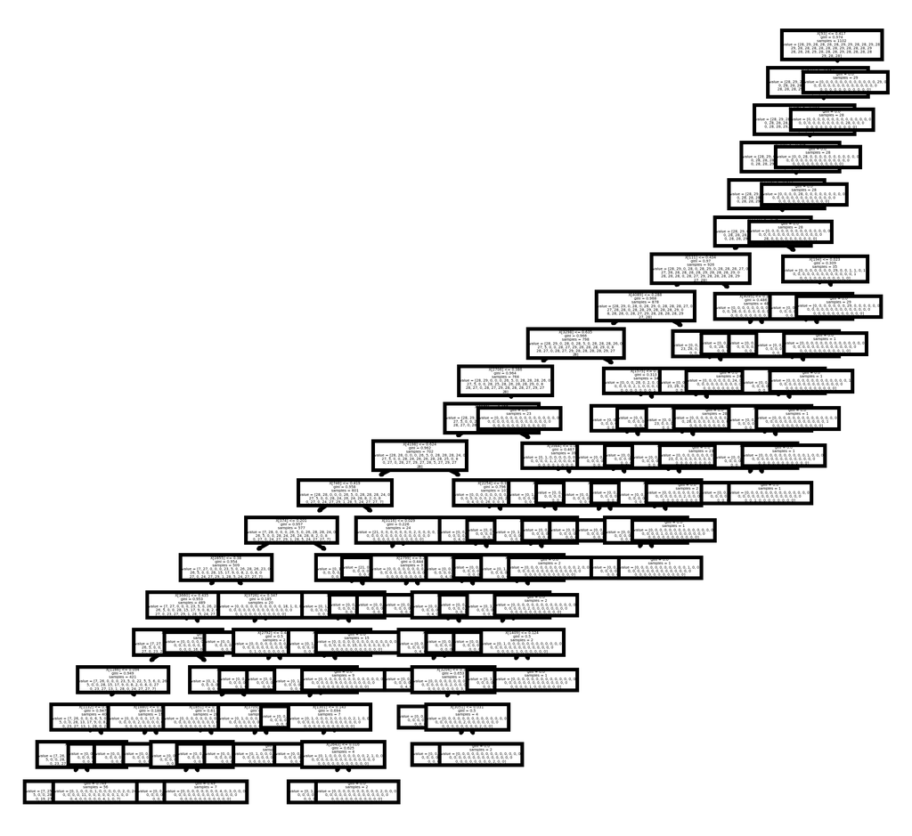

```python
#### Decision Tree depiction on test set classification
from sklearn.tree import DecisionTreeClassifier, plot_tree
fig = plt.gcf()
my_dpi=500
plt.figure(figsize=(2000/my_dpi, 2000/my_dpi), dpi=my_dpi)
treeVis = tree.plot_tree(model_clf.fit(HOGX_test, HOGy_test))
```

We see here how the Decision Tree is splitting the images it encounters and assigns them to different classes. Image feature augmented data comes from the test set and the classifier has been trained according to hyperparameters set previously.

### 2.2 Classification on PCA augmented dataset

### 2.2.1 SVM on PCA

```python
#### Training/test set split
from sklearn.model_selection import train_test_split
PCAX_train, PCAX_test, PCAy_train, PCAy_test = train_test_split(PCA_repo_ros, PCA_target_ros,
                                                    stratify=PCA_target_ros,
                                                    test_size=0.25, random_state=40)
```

```python
#### train/test set split proof
print(len(PCAX_train)," ", PCAX_train.shape)
print(len(PCAX_test), " ", PCAX_test.shape)
print(len(PCAy_train), " ", PCAy_train.shape)
print(len(PCAy_test), " ", PCAy_test.shape)
```

```
3305   (3305, 9)
1102   (1102, 9)
3305   (3305,)
1102   (1102,)
```

```python
#### Train a SVM model to predict the labels of the test data
from sklearn import svm
model_svm  = svm.SVC(gamma='auto', random_state=42)
PCAclf_svm = model_svm.fit(PCAX_train, PCAy_train)
PCAy_svm = PCAclf_svm.predict(PCAX_test)
```

```python
print(PCAy_svm,PCAy_svm.shape)
```

```
[16. 28. 15. ... 28. 15.  2.] (1102,)
```

```python
#### Metrics on SVM
from sklearn.metrics import accuracy_score
PCAacc_SVM = accuracy_score(PCAy_test,PCAy_svm)
print('Accuracy of SVM: ', round(PCAacc_SVM,3))
# since dataset is balanced ROC might not do the work. Recall is used instead.

from sklearn.metrics import recall_score
PCARecallSc_SVM = recall_score(PCAy_test,PCAy_svm, average='macro', zero_division=1)
print('Recall of SVM: ', round(PCARecallSc_SVM,3))

from sklearn.metrics import precision_score
PCApres_SVM = precision_score(PCAy_test,PCAy_svm, average='macro',zero_division=1)
print('Precision of SVM: ', round(PCApres_SVM,3))

from sklearn.metrics import f1_score
PCAF1_Sc_SVM = f1_score(PCAy_test,PCAy_svm, average='macro',zero_division=1)
print('F1_score of SVM: ', round(PCAF1_Sc_SVM,3))

from sklearn.metrics import cohen_kappa_score
PCAkapa_SVM = cohen_kappa_score(PCAy_test, PCAy_svm)
print('kappa-score: ', round(PCAkapa_SVM, 3))

from sklearn.metrics import matthews_corrcoef
PCA_MCC_SVM = matthews_corrcoef(PCAy_test, PCAy_svm)
print('MCC: ', round(PCA_MCC_SVM,3))
```

```
Accuracy of SVM:  0.157
Recall of SVM:  0.158
Precision of SVM:  0.542
F1_score of SVM:  0.092
kappa-score:  0.135
MCC:  0.144
```

```python
#### Cross validatig the original data (the function will do it all)
from sklearn.model_selection import cross_validate

PCAcross_val_scores_svm = cross_validate(model_svm, PCA_repo_ros, PCA_target_ros, cv=5)
print('SVM cross-validated scores: ', PCAcross_val_scores_svm)
```

```
SVM cross-validated scores:  {'fit_time': array([0.79454231, 0.8035605 , 0.7715764 , 0.78754616, 0.8177433 ]), 'score_time': array([0.20388222, 0.20386434, 0.20388341, 0.20190501, 0.20687985]), 'test_score': array([0.16326531, 0.14172336, 0.138479  , 0.14188422, 0.14188422])}
```

```python
#### Evaluating Accuracy for each fold
PCAval_acc_SVM = cross_val_score(model_svm, PCA_repo_ros, PCA_target_ros, cv=5, scoring = 'accuracy')
print('Accuracy for SVM: ', PCAval_acc_SVM)

#### Evaluating Mean Accuracy for all folds
print('Mean Accuracy for SVM: ',round(np.mean(PCAval_acc_SVM),2))
```

```
Accuracy for SVM:  [0.16326531 0.14172336 0.138479   0.14188422 0.14188422]
Mean Accuracy for SVM:  0.15
```

```python
#### Evaluating Precision, Recall and F1-score (both by fold and average)
PCAprecisionVal_SVM = cross_val_score(model_svm, PCA_repo_ros, PCA_target_ros, cv=5, scoring = 'precision_macro')
MeanPCAprecisionVal_SVM = round(np.mean(PCAprecisionVal_SVM),2)

PCArecallVal_SVM = cross_val_score(model_svm, PCA_repo_ros, PCA_target_ros, cv=5, scoring = 'recall_macro')
MeanPCArecallVal_SVM = round(np.mean(PCArecallVal_SVM),2)

PCAF1Val_SVM = cross_val_score(model_svm, PCA_repo_ros, PCA_target_ros, cv=5, scoring = 'f1_macro')
MeanPCAF1Val_SVM = round(np.mean(PCAF1Val_SVM),2)

print('Precision for SVM: ', PCAprecisionVal_SVM)
print('Mean Precision for SVM: ', MeanPCAprecisionVal_SVM)
print()
print('Recall for SVM: ', PCArecallVal_SVM)
print('Mean Recall for SVM: ',MeanPCArecallVal_SVM)
print()
print('F1-Score for SVM: ', PCAF1Val_SVM)
print('Mean F1-Score for SVM: ', MeanPCAF1Val_SVM)
```

```
Precision for SVM:  [0.07781055 0.10037148 0.08082791 0.074585   0.10968636]
Mean Precision for SVM:  0.09

Recall for SVM:  [0.16458903 0.14477551 0.14219114 0.14462349 0.14406608]
Mean Recall for SVM:  0.15

F1-Score for SVM:  [0.08120185 0.08550566 0.08390377 0.07421138 0.07712658]
Mean F1-Score for SVM:  0.08
```

### 2.2.2 Random Forest on PCA

```python
#### Use this cell to train a RF model to predict the labels of the test data
from sklearn.ensemble import RandomForestClassifier
model_rf = RandomForestClassifier(n_estimators=10,random_state=0)
PCAclf_rf = model_rf.fit(PCAX_train, PCAy_train)
PCAy_rf = PCAclf_rf.predict(PCAX_test)
```

```python
#### metrics on Random Forest
from sklearn.metrics import accuracy_score
PCAacc_rf =  accuracy_score(PCAy_test,PCAy_rf)
print('Accuracy of RF: ', round(PCAacc_rf,2))
# since dataset is balanced ROC might not do the work. Recall is used instead.

from sklearn.metrics import recall_score
PCARecallSc_rf = recall_score(PCAy_test,PCAy_rf, average='macro', zero_division=1)
print('Recall of RF: ', round(PCARecallSc_rf,2))

from sklearn.metrics import precision_score
PCApres_rf = precision_score(PCAy_test,PCAy_rf, average='macro', zero_division=1)
print('Precision of RF: ', round(PCApres_rf,2))

from sklearn.metrics import f1_score
PCAF1_Sc_rf = f1_score(PCAy_test,PCAy_rf, average='macro', zero_division=1)
print('F1_score of RF: ', round(PCAF1_Sc_rf,2))

from sklearn.metrics import cohen_kappa_score
PCAkapa_rf = cohen_kappa_score(PCAy_test, PCAy_rf)
print('kappa-score: ', round(PCAkapa_rf, 3))

from sklearn.metrics import matthews_corrcoef
PCA_MCC_rf = matthews_corrcoef(PCAy_test, PCAy_rf)
print('MCC: ', round(PCA_MCC_rf,3))
```

```
Accuracy of RF:  0.86
Recall of RF:  0.86
Precision of RF:  0.89
F1_score of RF:  0.86
kappa-score:  0.855
MCC:  0.856
```

```python
#### Cross validatig the original data (the function will do it all)
PCAscores_rf = cross_validate(model_rf, PCA_repo_ros, PCA_target_ros, cv=5)
print('RF cross-validated scores: ', PCAscores_rf)
```

```
RF cross-validated scores:  {'fit_time': array([0.05796719, 0.05796194, 0.07995296, 0.06096435, 0.05696607]), 'score_time': array([0.00599957, 0.00899601, 0.00600123, 0.00500011, 0.00500011]), 'test_score': array([0.80839002, 0.85600907, 0.85357548, 0.86719637, 0.87060159])}
```

```python
#### Evaluating Accuracy for each fold
PCAval_acc_rf = cross_val_score(model_rf, PCA_repo_ros, PCA_target_ros, cv=5, scoring = 'accuracy')
print('Accuracy for RF: ', PCAval_acc_rf)
#### Evaluating Mean Accuracy for all folds
print('Mean Accuracy for RF: ', round(np.mean(PCAval_acc_rf),2))
```

```
Accuracy for RF:  [0.80839002 0.85600907 0.85357548 0.86719637 0.87060159]
Mean Accuracy for RF:  0.85
```

```python
#### Evaluating Precision, Recall and F1-score (both by fold and average)
PCAprecisionVal_rf = cross_val_score(model_rf, PCA_repo_ros, PCA_target_ros, cv=5, scoring = 'precision_macro')
MeanPCAprecisionVal_rf = round(np.mean(PCAprecisionVal_rf),2)

PCArecallVal_rf = cross_val_score(model_rf, PCA_repo_ros, PCA_target_ros, cv=5, scoring = 'recall_macro')
MeanPCArecallVal_rf = round(np.mean(PCArecallVal_rf),2)

PCAF1Val_rf = cross_val_score(model_rf, PCA_repo_ros, PCA_target_ros, cv=5, scoring = 'f1_macro')
MeanPCAF1Val_rf = round(np.mean(PCAF1Val_rf),2)

print('Precision for RF: ', PCAprecisionVal_rf)
print('Mean Precision for RF: ', MeanPCAprecisionVal_rf)
print()
print('Recall for RF: ', PCArecallVal_rf)
print('Mean Recall for RF: ',MeanPCArecallVal_rf)
print()
print('F1-Score for RF: ', PCAF1Val_rf)
print('Mean F1-Score for RF: ', MeanPCAF1Val_rf)
```

```
Precision for RF:  [0.83781263 0.8858382  0.88686998 0.9008809  0.90217803]
Mean Precision for RF:  0.88

Recall for RF:  [0.80865511 0.85608594 0.85319753 0.86647411 0.87118678]
Mean Recall for RF:  0.85

F1-Score for RF:  [0.80997817 0.85879901 0.85376213 0.87037458 0.87416276]
Mean F1-Score for RF:  0.85
```

### 2.2.3 Decision Tree on PCA

```python
#### train Decision Tree model
from sklearn.datasets import load_iris
from sklearn import tree
import math

PCAmodel_clf = tree.DecisionTreeClassifier(criterion='gini', max_depth=20 ,random_state=40)
PCAclf_des = PCAmodel_clf.fit(PCAX_train, PCAy_train)
PCAy_des = PCAclf_des.predict(PCAX_test)
```

```python
#### metrics on Decision Trees
from sklearn.metrics import accuracy_score
PCAacc_des = accuracy_score(PCAy_test, PCAy_des)
print('Accuracy of DT: ', round(PCAacc_des,2))

from sklearn.metrics import recall_score
PCARecallSc_des = recall_score(PCAy_test,PCAy_des, average='macro', zero_division=1)
print('Recall of DT: ', round(PCARecallSc_des,2))

from sklearn.metrics import precision_score
PCApres_des = precision_score(PCAy_test,PCAy_des, average='macro')
print('Precision of DT: ', round(PCApres_des,2))

from sklearn.metrics import f1_score
PCAF1_Sc_des = f1_score(PCAy_test,PCAy_des, average='macro')
print('F1_score of DT: ', round(PCAF1_Sc_des,2))

from sklearn.metrics import cohen_kappa_score
PCAkapa_des = cohen_kappa_score(PCAy_test, PCAy_des)
print('kappa-score: ', round(PCAkapa_des, 3))

from sklearn.metrics import matthews_corrcoef
PCA_MCC_des = matthews_corrcoef(PCAy_test, PCAy_des)
print('MCC: ', round(PCA_MCC_des,3))
```

```
Accuracy of DT:  0.86
Recall of DT:  0.86
Precision of DT:  0.89
F1_score of DT:  0.86
kappa-score:  0.857
MCC:  0.858
```

```python
#### Cross validatig the original data (the function will do it all)
from sklearn.model_selection import cross_validate
PCAval_scores_des = cross_validate(PCAmodel_clf, PCA_repo_ros, PCA_target_ros, cv=5)
print('DT cross-validated scores: ', PCAval_scores_des)
```

```
DT cross-validated scores:  {'fit_time': array([0.01199269, 0.01199341, 0.01399136, 0.00799131, 0.00899482]), 'score_time': array([0.00100088, 0.00099897, 0.00100017, 0.00099969, 0.00100064]), 'test_score': array([0.81632653, 0.85600907, 0.84790011, 0.86719637, 0.87400681])}
```

```python
#### Evaluating Accuracy for each fold
from sklearn.model_selection import cross_val_score
PCAcrossValSccore_des = cross_val_score(PCAmodel_clf, PCA_repo_ros, PCA_target_ros, cv=5, scoring = 'accuracy')
print('Accuracy for DT: ', PCAcrossValSccore_des)
#### Evaluating Mean Accuracy for all folds
print('Mean Accuracy for DT: ',round(np.mean(PCAcrossValSccore_des),2))
```

```
Accuracy for DT:  [0.81632653 0.85600907 0.84790011 0.86719637 0.87400681]
Mean Accuracy for DT:  0.85
```

```python
#### Evaluating Precision, Recall and F1-score (both by fold and average)
PCAval_pres_des = cross_val_score(PCAmodel_clf, PCA_repo_ros, PCA_target_ros, cv=5, scoring = 'precision_macro')
print('Precision for DT: ', PCAval_pres_des)
print('Mean Precision for DT: ',round(np.mean(PCAval_pres_des),2))
print()
PCAval_recall_des =cross_val_score(PCAmodel_clf, PCA_repo_ros, PCA_target_ros, cv=5, scoring = 'recall_macro')
print('Recall for DT: ',PCAval_recall_des)
print('Mean Recall for DT: ', round(np.mean(PCAval_recall_des),2))
print()
PCAval_F1sc_des =cross_val_score(PCAmodel_clf, PCA_repo_ros, PCA_target_ros, cv=5, scoring = 'f1_macro')
print('F1-Score for DT: ', PCAval_F1sc_des)
print('Mean F1-Score for DT: ', round(np.mean(PCAval_F1sc_des),2))
```

```
Precision for DT:  [0.8517021  0.88385304 0.87887216 0.90015231 0.90340739]
Mean Precision for DT:  0.88

Recall for DT:  [0.81650958 0.85623796 0.8474207  0.86662613 0.87448059]
Mean Recall for DT:  0.85

F1-Score for DT:  [0.81745259 0.85856383 0.84777358 0.86980198 0.87800531]
Mean F1-Score for DT:  0.85
```

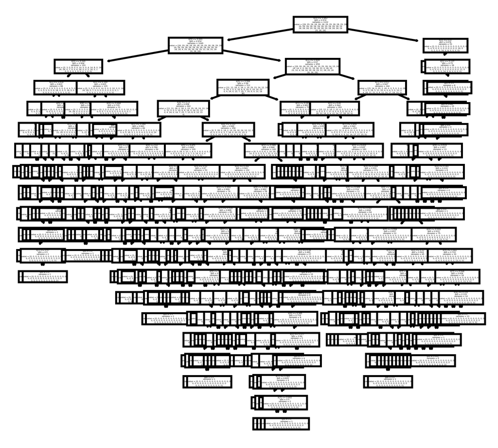

```python
#### Decision Tree depiction on test set classification
from sklearn.tree import DecisionTreeClassifier, plot_tree
fig = plt.gcf()
my_dpi=500
plt.figure(figsize=(2000/my_dpi, 2000/my_dpi), dpi=my_dpi)
treeVis = tree.plot_tree(PCAmodel_clf.fit(PCAX_test, PCAy_test))
```

We see here how the Decision Tree is splitting the images it encounters and assigns them to different classes. Image feature augmented data comes from the test set and the classifier has been trained according to hyperparameters set previously.

### 2.3 Classification on k-means decomposed HOG feature augmented dataset

### 2.3.1 SVM on k-means decomposed HOG feature augmented dataset

```python
#### Training/test set split
from sklearn.model_selection import train_test_split
decHOGX_train, decHOGX_test, decHOGy_train, decHOGy_test = train_test_split(decHOGrepo_ros, decHOGtarget_ros,
                                                    stratify=decHOGtarget_ros,
                                                    test_size=0.25, random_state = 40)
```

```python
#### train/test set split proof
print(len(decHOGX_train)," ", decHOGX_train.shape)
print(len(decHOGX_test), " ", decHOGX_test.shape)
print(len(decHOGy_train), " ", decHOGy_train.shape)
print(len(decHOGy_test), " ", decHOGy_test.shape)
```

```
3266   (3266, 4356)
1089   (1089, 4356)
3266   (3266,)
1089   (1089,)
```

```python
#### Use this cell to train a SVM model to predict the labels of the test data
from sklearn import svm
decmodel_svm  = svm.SVC(gamma='auto', random_state=40)
decHOGclf_svm = decmodel_svm.fit(decHOGX_train, decHOGy_train)
decHOGy_svm = decHOGclf_svm.predict(decHOGX_test)
```

```python
print(decHOGy_svm,decHOGy_svm.shape)
```

```
[16  8 46 ...  9 63 42] (1089,)
```

```python
#### Metrics of svm model
import math
from sklearn.metrics import accuracy_score
decHOGaccurSVM = accuracy_score(decHOGy_test,decHOGy_svm)
print('Accuracy of SVM: ', round(decHOGaccurSVM,3))


from sklearn.metrics import recall_score
decRecallSc = recall_score(decHOGy_test,decHOGy_svm, average='macro', zero_division=1)
print('Recall of SVM: ', round(decRecallSc,3))

from sklearn.metrics import precision_score
decHOGpresSVM = precision_score(decHOGy_test,decHOGy_svm, average='macro',zero_division=1)
print('Precision of SVM: ', round(decHOGpresSVM,3))

from sklearn.metrics import f1_score
decHOGF1_ScSVM = f1_score(decHOGy_test,decHOGy_svm, average='macro',zero_division=1)
print('F1_score: ', round(decHOGF1_ScSVM,3))


from sklearn.metrics import confusion_matrix, cohen_kappa_score
decHOGkapaSVM = cohen_kappa_score(decHOGy_test, decHOGy_svm)
print('kappa-score: ', round(decHOGkapaSVM, 3))

from sklearn.metrics import matthews_corrcoef
decHOG_MCC_SVM = matthews_corrcoef(decHOGy_test, decHOGy_svm)
print('MCC: ', round(decHOG_MCC_SVM,3))
```

```
Accuracy of SVM:  0.518
Recall of SVM:  0.523
Precision of SVM:  0.889
F1_score:  0.483
kappa-score:  0.511
MCC:  0.528
```

```python
#### Cross validatig the original data (the function will do it all)
from sklearn.model_selection import cross_validate
decHOGval_scores_svm = cross_validate(decmodel_svm, decHOGrepo_ros, decHOGtarget_ros, cv=5)
print('SVM cross-validated scores: ', decHOGval_scores_svm)
```

```
SVM cross-validated scores:  {'fit_time': array([109.69975805, 108.46183205, 108.53967881, 113.54642773,
       109.03263664]), 'score_time': array([14.18651867, 14.17088985, 14.21776032, 14.86905742, 14.63304591]), 'test_score': array([0.65671642, 0.673938  , 0.65671642, 0.6326062 , 0.66704937])}
```

```python
from sklearn.model_selection import cross_val_score
#### Evaluating Accuracy for each fold
decHOGvalAccSVM = cross_val_score(decmodel_svm, decHOGrepo_ros, decHOGtarget_ros, cv=5, scoring = 'accuracy')
print('Accuracy for SVM: ', decHOGvalAccSVM)

#### Evaluating Mean Accuracy for all folds
print('Mean Accuracy for SVM: ',round(np.mean(decHOGvalAccSVM),2))
```

```
Accuracy for SVM:  [0.65671642 0.673938   0.65671642 0.6326062  0.66704937]
Mean Accuracy for SVM:  0.66
```

```python
#### Evaluating Precision, Recall and F1-score (both by fold and average)
decHOGprecisionVal_SVM = cross_val_score(decmodel_svm, decHOGrepo_ros, decHOGtarget_ros, cv=5, scoring = 'precision_macro')
decMeanHOGprecisionVal_SVM = round(np.mean(decHOGprecisionVal_SVM),2)


decHOGrecallVal_SVM = cross_val_score(decmodel_svm, decHOGrepo_ros, decHOGtarget_ros, cv=5, scoring = 'recall_macro')
decMeanHOGrecallVal_SVM = round(np.mean(decHOGrecallVal_SVM),2)

decHOGF1Val_SVM = cross_val_score(decmodel_svm, decHOGrepo_ros, decHOGtarget_ros, cv=5, scoring = 'f1_macro')
decMeanHOGF1Val_SVM = round(np.mean(decHOGF1Val_SVM),2)

print('Precision for SVM: ', decHOGprecisionVal_SVM)
print('Mean Precision for SVM: ', decMeanHOGprecisionVal_SVM)
print()
print('Recall for SVM: ', decHOGrecallVal_SVM)
print('Mean Recall for SVM: ',decMeanHOGrecallVal_SVM)
print()
print('F1-Score for SVM: ', decHOGF1Val_SVM)
print('Mean F1-Score for SVM: ', decMeanHOGF1Val_SVM)
```

```
Precision for SVM:  [0.63127791 0.66829013 0.60983268 0.61264249 0.61568082]
Mean Precision for SVM:  0.63

Recall for SVM:  [0.66728656 0.6830093  0.66804734 0.64395604 0.6783601 ]
Mean Recall for SVM:  0.67

F1-Score for SVM:  [0.61323172 0.63772448 0.60763821 0.59309816 0.61888523]
Mean F1-Score for SVM:  0.61
```

### 2.3.2 Random Forest on k-means decomposed HOG feature augmented dataset

```python
#### Training RF model to predict the labels of the test data
from sklearn.ensemble import RandomForestClassifier
decmodel_rf = RandomForestClassifier(n_estimators=10,random_state=0)
decHOGclf_rf = decmodel_rf.fit(decHOGX_train, decHOGy_train)
decHOGy_rf = decHOGclf_rf.predict(decHOGX_test)
```

```python
#### Metrics for Random Forest
from sklearn.metrics import accuracy_score
decHOGacc_rf = accuracy_score(decHOGy_test,decHOGy_rf)
print('Accuracy of RF: ', round(decHOGacc_rf,3))

from sklearn.metrics import recall_score
decHOGRecallSc_rf = recall_score(decHOGy_test,decHOGy_rf, average='macro',zero_division=1)
print('Recall of RF: ', round(decHOGRecallSc_rf,3))

from sklearn.metrics import precision_score
decHOGpres_rf = precision_score(decHOGy_test, decHOGy_rf,average='macro', zero_division=1)
print('Precision of RF: ', round(decHOGpres_rf,3))

from sklearn.metrics import f1_score
decHOGF1_Sc_rf = f1_score(decHOGy_test,decHOGy_rf, average='macro',zero_division=1)
print('F1_score of RF: ', round(decHOGF1_Sc_rf,3))

from sklearn.metrics import matthews_corrcoef
decHOG_MCC_rf = matthews_corrcoef(decHOGy_test, decHOGy_rf)
print('MCC: ', round(decHOG_MCC_rf,3))

from sklearn.metrics import confusion_matrix, cohen_kappa_score
decHOGkapa_rf = cohen_kappa_score(decHOGy_test, decHOGy_rf)
print('kappa-score: ', round(decHOGkapa_rf, 3))
```

```
Accuracy of RF:  0.976
Recall of RF:  0.976
Precision of RF:  0.977
F1_score of RF:  0.976
MCC:  0.976
kappa-score:  0.976
```

```python
from sklearn.model_selection import cross_val_score
#### Evaluating Accuracy for each fold
decHOGvalAcc_rf = cross_val_score(decmodel_rf, decHOGrepo_ros, decHOGtarget_ros, cv=5, scoring = 'accuracy')
print('Accuracy for SVM: ', decHOGvalAcc_rf)

#### Evaluating Mean Accuracy for all folds
print('Mean Accuracy for SVM: ',round(np.mean(decHOGvalAcc_rf),2))
```

```
Accuracy for SVM:  [0.95063146 0.94833525 0.96900115 0.9793341  0.98966705]
Mean Accuracy for SVM:  0.97
```

```python
#### Evaluating Precision, Recall and F1-score (both by fold and average)
decHOGprecisionVal_rf = cross_val_score(decmodel_rf, decHOGrepo_ros, decHOGtarget_ros, cv=5, scoring = 'precision_macro')
decMeanHOGprecisionVal_rf = round(np.mean(decHOGprecisionVal_rf),2)


decHOGrecallVal_rf = cross_val_score(decmodel_rf, decHOGrepo_ros, decHOGtarget_ros, cv=5, scoring = 'recall_macro')
decMeanHOGrecallVal_rf = round(np.mean(decHOGrecallVal_rf),2)

decHOGF1Val_rf = cross_val_score(decmodel_rf, decHOGrepo_ros, decHOGtarget_ros, cv=5, scoring = 'f1_macro')
decMeanHOGF1Val_rf = round(np.mean(decHOGF1Val_rf),2)

print('Precision for RF: ', decHOGprecisionVal_rf)
print('Mean Precision for RF: ', decMeanHOGprecisionVal_rf)
print()
print('Recall for RF: ', decHOGrecallVal_rf)
print('Mean Recall for RF: ',decMeanHOGrecallVal_rf)
print()
print('F1-Score for RF: ', decHOGF1Val_rf)
print('Mean F1-Score for RF: ', decMeanHOGF1Val_rf)
```

```
Precision for RF:  [0.95639335 0.95030303 0.970966   0.98046267 0.99001832]
Mean Precision for RF:  0.97

Recall for RF:  [0.95105664 0.94801352 0.96838546 0.97886729 0.98994083]
Mean Recall for RF:  0.97

F1-Score for RF:  [0.95131385 0.94652683 0.96845523 0.97852268 0.98958048]
Mean F1-Score for RF:  0.97
```

### 2.3.3 Decision Trees on k-means decomposed HOG feature augmented dataset

```python
#### Decision tree model training

from sklearn import tree
import math

decmodel_clf = tree.DecisionTreeClassifier(criterion='gini', max_depth=40 ,random_state=40)
decHOGclf_des = decmodel_clf.fit(decHOGX_train, decHOGy_train)
decHOGy_des = decHOGclf_des.predict(decHOGX_test)
```

```python
#### Metrics on Decision Tree
from sklearn.metrics import accuracy_score
decHOGacc_des = accuracy_score(decHOGy_test,decHOGy_des)
print('Accuracy of DT: ', round(decHOGacc_des,3))

from sklearn.metrics import recall_score
decHOGRecallSc_des = recall_score(decHOGy_test,decHOGy_des, average='macro', zero_division=1)
print('Recall of DT: ', round(decHOGRecallSc_des,3))

from sklearn.metrics import precision_score
decHOGpres_des = precision_score(decHOGy_test,decHOGy_des, average='macro',zero_division=1)
print('Precision of DT: ', round(decHOGpres_des,3))

from sklearn.metrics import f1_score
decHOGF1_Sc_des = f1_score(decHOGy_test, decHOGy_des,average='macro')
print('F1_score of DT: ', round(decHOGF1_Sc_des,3))

from sklearn.metrics import cohen_kappa_score
decHOGkapa_des = cohen_kappa_score(decHOGy_test, decHOGy_des)
print('kappa-score: ', round(decHOGkapa_des, 3))

from sklearn.metrics import matthews_corrcoef
decHOG_MCC_des = matthews_corrcoef(decHOGy_test, decHOGy_des)
print('MCC: ', round(decHOG_MCC_des,3))
```

```
Accuracy of DT:  0.703
Recall of DT:  0.703
Precision of DT:  0.911
F1_score of DT:  0.756
kappa-score:  0.699
MCC:  0.723
```

```python
from sklearn.model_selection import cross_val_score
#### Evaluating Accuracy for each fold
decHOGvalAcc_des = cross_val_score(decmodel_clf, decHOGrepo_ros, decHOGtarget_ros, cv=5, scoring = 'accuracy')
print('Accuracy for DT: ', decHOGvalAcc_des)

#### Evaluating Mean Accuracy for all folds
print('Mean Accuracy for DT: ',round(np.mean(decHOGvalAcc_des),2))
```

```
Accuracy for DT:  [0.75200918 0.71297359 0.7554535  0.76234214 0.89207807]
Mean Accuracy for DT:  0.77
```

```python
#### Evaluating Precision, Recall and F1-score (both by fold and average)
decHOGprecisionVal_des = cross_val_score(decmodel_clf, decHOGrepo_ros, decHOGtarget_ros, cv=5, scoring = 'precision_macro')
decMeanHOGprecisionVal_des = round(np.mean(decHOGprecisionVal_des),2)


decHOGrecallVal_des = cross_val_score(decmodel_clf, decHOGrepo_ros, decHOGtarget_ros, cv=5, scoring = 'recall_macro')
decMeanHOGrecallVal_des = round(np.mean(decHOGrecallVal_des),2)

decHOGF1Val_des = cross_val_score(decmodel_clf, decHOGrepo_ros, decHOGtarget_ros, cv=5, scoring = 'f1_macro')
decMeanHOGF1Val_des = round(np.mean(decHOGF1Val_des),2)

print('Precision for DT: ', decHOGprecisionVal_des)
print('Mean Precision for DT: ', decMeanHOGprecisionVal_des)
print()
print('Recall for DT: ', decHOGrecallVal_des)
print('Mean Recall for DT: ',decMeanHOGrecallVal_des)
print()
print('F1-Score for DT: ', decHOGF1Val_des)
print('Mean F1-Score for DT: ', decMeanHOGF1Val_des)
```

```
Precision for DT:  [0.87537008 0.86131162 0.89970681 0.91674254 0.95200082]
Mean Precision for DT:  0.9

Recall for DT:  [0.75181741 0.7123415  0.75511412 0.76289096 0.8920541 ]
Mean Recall for DT:  0.77

F1-Score for DT:  [0.78501277 0.75090573 0.78445923 0.80249025 0.90893375]
Mean F1-Score for DT:  0.81
```

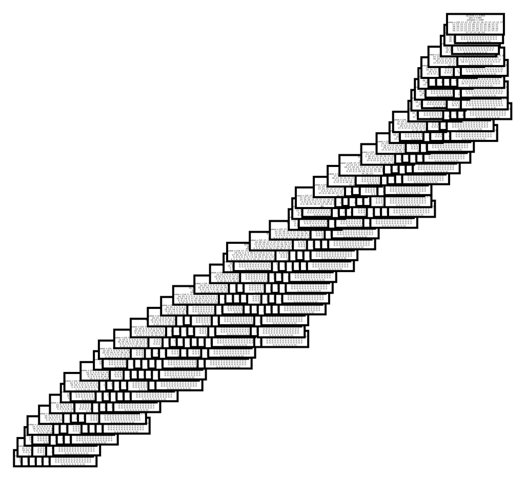

```python
#### Decision Tree depiction on test set classification
from sklearn.tree import DecisionTreeClassifier, plot_tree
fig = plt.gcf()
my_dpi=500
plt.figure(figsize=(2000/my_dpi, 2000/my_dpi), dpi=my_dpi)
treeVis = tree.plot_tree(decmodel_clf.fit(decHOGX_test, decHOGy_test))
```

We see here how the Decision Tree is splitting the images it encounters and assigns them to different classes. Image feature augmented data comes from the test set and the classifier has been trained according to hyperparameters set previously.

### 2.4 Classification on agglomerative clustering decomposed HOG feature augmented dataset

### 2.4.1 SVM on agglomerative clustering decomposed HOG feature augmented dataset

```python
#### Training/test set split
from sklearn.model_selection import train_test_split
decAGGHOGX_train, decAGGHOGX_test, decAGGHOGy_train, decAGGHOGy_test = train_test_split(decAGGHOGrepo_ros, decAGGHOGtarget_ros,
                                                    stratify=decAGGHOGtarget_ros,
                                                    test_size=0.25, random_state = 40)
```

```python
#### train/test set split proof
print(len(decAGGHOGX_train)," ", decAGGHOGX_train.shape)
print(len(decAGGHOGX_test), " ", decAGGHOGX_test.shape)
print(len(decAGGHOGy_train), " ", decAGGHOGy_train.shape)
print(len(decAGGHOGy_test), " ", decAGGHOGy_test.shape)
```

```
5557   (5557, 4356)
1853   (1853, 4356)
5557   (5557,)
1853   (1853,)
```

```python
#### Use this cell to train a SVM model to predict the labels of the test data
from sklearn import svm
AGGmodel_svm  = svm.SVC(gamma='auto', random_state=40)
decAGGHOGclf_svm = AGGmodel_svm.fit(decAGGHOGX_train, decAGGHOGy_train)
decAGGHOGy_svm = decAGGHOGclf_svm.predict(decAGGHOGX_test)
```

```python
#### Metrics of svm model
import math
from sklearn.metrics import accuracy_score
decAGGHOGaccurSVM = accuracy_score(decAGGHOGy_test,decAGGHOGy_svm)
print('Accuracy of SVM: ', round(decAGGHOGaccurSVM,3))


from sklearn.metrics import recall_score
decAGGRecallSc = recall_score(decAGGHOGy_test,decAGGHOGy_svm, average='macro', zero_division=1)
print('Recall of SVM: ', round(decAGGRecallSc,3))

from sklearn.metrics import precision_score
decAGGHOGpresSVM = precision_score(decAGGHOGy_test,decAGGHOGy_svm, average='macro',zero_division=1)
print('Precision of SVM: ', round(decAGGHOGpresSVM,3))

from sklearn.metrics import f1_score
decAGGHOGF1_ScSVM = f1_score(decAGGHOGy_test,decAGGHOGy_svm, average='macro',zero_division=1)
print('F1_score: ', round(decAGGHOGF1_ScSVM,3))


from sklearn.metrics import confusion_matrix, cohen_kappa_score
decAGGHOGkapaSVM = cohen_kappa_score(decAGGHOGy_test, decAGGHOGy_svm)
print('kappa-score: ', round(decAGGHOGkapaSVM, 3))

from sklearn.metrics import matthews_corrcoef
decAGGHOG_MCC_SVM = matthews_corrcoef(decAGGHOGy_test, decAGGHOGy_svm)
print('MCC: ', round(decAGGHOG_MCC_SVM,3))
```

```
Accuracy of SVM:  0.493
Recall of SVM:  0.517
Precision of SVM:  0.842
F1_score:  0.413
kappa-score:  0.491
MCC:  0.494
```

```python
#### Cross validatig the original data (the function will do it all)
from sklearn.model_selection import cross_validate
decAGGHOGval_scores_svm = cross_validate(AGGmodel_svm, decAGGHOGrepo_ros, decAGGHOGtarget_ros, cv=5)
print('SVM cross-validated scores: ', decAGGHOGval_scores_svm)
```

```
SVM cross-validated scores:  {'fit_time': array([332.41706586, 332.21270585, 332.74495411, 332.07968116,
       334.17901897]), 'score_time': array([44.03626299, 43.99694562, 43.58315134, 43.98983955, 44.21455312]), 'test_score': array([0.44804318, 0.43117409, 0.45681511, 0.50404858, 0.44871795])}
```

```python
from sklearn.model_selection import cross_val_score
#### Evaluating Accuracy for each fold
decAGGHOGvalAccSVM = cross_val_score(AGGmodel_svm, decAGGHOGrepo_ros, decAGGHOGtarget_ros, cv=5, scoring = 'accuracy')
print('Accuracy for SVM: ', decAGGHOGvalAccSVM)

#### Evaluating Mean Accuracy for all folds
print('Mean Accuracy for SVM: ',round(np.mean(decAGGHOGvalAccSVM),2))
```

```
Accuracy for SVM:  [0.44804318 0.43117409 0.45681511 0.50404858 0.44871795]
Mean Accuracy for SVM:  0.46
```

```python
#### Evaluating Precision, Recall and F1-score (both by fold and average)
decAGGHOGprecisionVal_SVM = cross_val_score(AGGmodel_svm, decAGGHOGrepo_ros, decAGGHOGtarget_ros, cv=5, scoring = 'precision_macro')
decAGGMeanHOGprecisionVal_SVM = round(np.mean(decAGGHOGprecisionVal_SVM),2)


decAGGHOGrecallVal_SVM = cross_val_score(AGGmodel_svm, decAGGHOGrepo_ros, decAGGHOGtarget_ros, cv=5, scoring = 'recall_macro')
decAGGMeanHOGrecallVal_SVM = round(np.mean(decAGGHOGrecallVal_SVM),2)

decAGGHOGF1Val_SVM = cross_val_score(AGGmodel_svm, decAGGHOGrepo_ros, decAGGHOGtarget_ros, cv=5, scoring = 'f1_macro')
decAGGMeanHOGF1Val_SVM = round(np.mean(decAGGHOGF1Val_SVM),2)

print('Precision for SVM: ', decAGGHOGprecisionVal_SVM)
print('Mean Precision for SVM: ', decAGGMeanHOGprecisionVal_SVM)
print()
print('Recall for SVM: ', decAGGHOGrecallVal_SVM)
print('Mean Recall for SVM: ',decMeanHOGrecallVal_SVM)
print()
print('F1-Score for SVM: ', decAGGHOGF1Val_SVM)
print('Mean F1-Score for SVM: ', decAGGMeanHOGF1Val_SVM)
```

[output not shown]

### 2.4.2 Random Forest on agglomerative clustering decomposed HOG feature augmented dataset

```python
#### Training RF model to predict the labels of the test data
from sklearn.ensemble import RandomForestClassifier
decAGGmodel_rf = RandomForestClassifier(n_estimators=10,random_state=0)
decAGGHOGclf_rf = decAGGmodel_rf.fit(decAGGHOGX_train, decAGGHOGy_train)
decAGGHOGy_rf = decAGGHOGclf_rf.predict(decAGGHOGX_test)
```

```python
#### Metrics for Random Forest
from sklearn.metrics import accuracy_score
decAGGHOGacc_rf = accuracy_score(decAGGHOGy_test,decAGGHOGy_rf)
print('Accuracy of RF: ', round(decAGGHOGacc_rf,3))

from sklearn.metrics import recall_score
decAGGHOGRecallSc_rf = recall_score(decAGGHOGy_test,decAGGHOGy_rf, average='macro',zero_division=1)
print('Recall of RF: ', round(decAGGHOGRecallSc_rf,3))

from sklearn.metrics import precision_score
decAGGHOGpres_rf = precision_score(decAGGHOGy_test, decAGGHOGy_rf,average='macro', zero_division=1)
print('Precision of RF: ', round(decAGGHOGpres_rf,3))

from sklearn.metrics import f1_score
decAGGHOGF1_Sc_rf = f1_score(decAGGHOGy_test,decAGGHOGy_rf, average='macro',zero_division=1)
print('F1_score of RF: ', round(decAGGHOGF1_Sc_rf,3))

from sklearn.metrics import matthews_corrcoef
decAGGHOG_MCC_rf = matthews_corrcoef(decAGGHOGy_test, decAGGHOGy_rf)
print('MCC: ', round(decAGGHOG_MCC_rf,3))

from sklearn.metrics import confusion_matrix, cohen_kappa_score
decAGGHOGkapa_rf = cohen_kappa_score(decAGGHOGy_test, decAGGHOGy_rf)
print('kappa-score: ', round(decAGGHOGkapa_rf, 3))
```

```
Accuracy of RF:  0.988
Recall of RF:  0.988
Precision of RF:  0.989
F1_score of RF:  0.987
MCC:  0.988
kappa-score:  0.988
```

```python
from sklearn.model_selection import cross_val_score
#### Evaluating Accuracy for each fold
decAGGHOGvalAcc_rf = cross_val_score(decAGGmodel_rf, decAGGHOGrepo_ros, decAGGHOGtarget_ros, cv=5, scoring = 'accuracy')
print('Accuracy for SVM: ', decAGGHOGvalAcc_rf)

#### Evaluating Mean Accuracy for all folds
print('Mean Accuracy for SVM: ',round(np.mean(decAGGHOGvalAcc_rf),2))
```

```
Accuracy for SVM:  [0.9757085  0.98043185 0.98717949 0.99122807 0.99865047]
Mean Accuracy for SVM:  0.99
```

```python
#### Evaluating Precision, Recall and F1-score (both by fold and average)
decAGGHOGprecisionVal_rf = cross_val_score(decAGGmodel_rf, decAGGHOGrepo_ros, decAGGHOGtarget_ros, cv=5, scoring = 'precision_macro')
decAGGMeanHOGprecisionVal_rf = round(np.mean(decAGGHOGprecisionVal_rf),2)


decAGGHOGrecallVal_rf = cross_val_score(decAGGmodel_rf, decAGGHOGrepo_ros, decAGGHOGtarget_ros, cv=5, scoring = 'recall_macro')
decAGGMeanHOGrecallVal_rf = round(np.mean(decAGGHOGrecallVal_rf),2)

decAGGHOGF1Val_rf = cross_val_score(decAGGmodel_rf, decAGGHOGrepo_ros, decAGGHOGtarget_ros, cv=5, scoring = 'f1_macro')
decAGGMeanHOGF1Val_rf = round(np.mean(decAGGHOGF1Val_rf),2)

print('Precision for RF: ', decAGGHOGprecisionVal_rf)
print('Mean Precision for RF: ', decAGGMeanHOGprecisionVal_rf)
print()
print('Recall for RF: ', decAGGHOGrecallVal_rf)
print('Mean Recall for RF: ',decAGGMeanHOGrecallVal_rf)
print()
print('F1-Score for RF: ', decAGGHOGF1Val_rf)
print('Mean F1-Score for RF: ', decAGGMeanHOGF1Val_rf)
```

```
Precision for RF:  [0.97738095 0.98229548 0.98817664 0.9922385  0.9988604 ]
Mean Precision for RF:  0.99

Recall for RF:  [0.9753663  0.98040293 0.98727106 0.99148352 0.9985348 ]
Mean Recall for RF:  0.99

F1-Score for RF:  [0.97373911 0.97922037 0.98668819 0.99082005 0.99854198]
Mean F1-Score for RF:  0.99
```

### 2.4.3 Decision trees on agglomerative clustering decomposed HOG feature augmented dataset

```python
#### Decision tree model training

from sklearn import tree
import math

decAGGmodel_clf = tree.DecisionTreeClassifier(criterion='gini', max_depth=70 ,random_state=40)
decAGGHOGclf_des = decAGGmodel_clf.fit(decAGGHOGX_train, decAGGHOGy_train)
decAGGHOGy_des = decAGGHOGclf_des.predict(decAGGHOGX_test)
```

```python
#### Metrics on Decision Tree
from sklearn.metrics import accuracy_score
decAGGHOGacc_des = accuracy_score(decAGGHOGy_test,decAGGHOGy_des)
print('Accuracy of DT: ', round(decAGGHOGacc_des,3))

from sklearn.metrics import recall_score
decAGGHOGRecallSc_des = recall_score(decAGGHOGy_test,decAGGHOGy_des, average='macro', zero_division=1)
print('Recall of DT: ', round(decAGGHOGRecallSc_des,3))

from sklearn.metrics import precision_score
decAGGHOGpres_des = precision_score(decAGGHOGy_test,decAGGHOGy_des, average='macro',zero_division=1)
print('Precision of DT: ', round(decAGGHOGpres_des,3))

from sklearn.metrics import f1_score
decAGGHOGF1_Sc_des = f1_score(decAGGHOGy_test, decAGGHOGy_des,average='macro')
print('F1_score of DT: ', round(decAGGHOGF1_Sc_des,3))

from sklearn.metrics import cohen_kappa_score
decAGGHOGkapa_des = cohen_kappa_score(decAGGHOGy_test, decAGGHOGy_des)
print('kappa-score: ', round(decAGGHOGkapa_des, 3))

from sklearn.metrics import matthews_corrcoef
decAGGHOG_MCC_des = matthews_corrcoef(decAGGHOGy_test, decAGGHOGy_des)
print('MCC: ', round(decAGGHOG_MCC_des,3))
```

```
Accuracy of DT:  0.535
Recall of DT:  0.537
Precision of DT:  0.969
F1_score of DT:  0.548
kappa-score:  0.532
MCC:  0.589
```

```python
from sklearn.model_selection import cross_val_score
#### Evaluating Accuracy for each fold
decAGGHOGvalAcc_des = cross_val_score(decAGGmodel_clf, decAGGHOGrepo_ros, decAGGHOGtarget_ros, cv=5, scoring = 'accuracy')
print('Accuracy for DT: ', decAGGHOGvalAcc_des)

#### Evaluating Mean Accuracy for all folds
print('Mean Accuracy for DT: ',round(np.mean(decAGGHOGvalAcc_des),2))
```

```
Accuracy for DT:  [0.55465587 0.63630229 0.55937922 0.52968961 0.56140351]
Mean Accuracy for DT:  0.57
```

```python
#### Evaluating Precision, Recall and F1-score (both by fold and average)
decAGGHOGprecisionVal_des = cross_val_score(decAGGmodel_clf, decAGGHOGrepo_ros, decAGGHOGtarget_ros, cv=5, scoring = 'precision_macro')
decAGGMeanHOGprecisionVal_des = round(np.mean(decAGGHOGprecisionVal_des),2)


decAGGHOGrecallVal_des = cross_val_score(decAGGmodel_clf, decAGGHOGrepo_ros, decAGGHOGtarget_ros, cv=5, scoring = 'recall_macro')
decAGGMeanHOGrecallVal_des = round(np.mean(decAGGHOGrecallVal_des),2)

decAGGHOGF1Val_des = cross_val_score(decAGGmodel_clf, decAGGHOGrepo_ros, decAGGHOGtarget_ros, cv=5, scoring = 'f1_macro')
decAGGMeanHOGF1Val_des = round(np.mean(decAGGHOGF1Val_des),2)

print('Precision for DT: ', decAGGHOGprecisionVal_des)
print('Mean Precision for DT: ', decAGGMeanHOGprecisionVal_des)
print()
print('Recall for DT: ', decAGGHOGrecallVal_des)
print('Mean Recall for DT: ',decAGGMeanHOGrecallVal_des)
print()
print('F1-Score for DT: ', decAGGHOGF1Val_des)
print('Mean F1-Score for DT: ', decAGGMeanHOGF1Val_des)
```

```
Precision for DT:  [0.66115819 0.74593343 0.65374759 0.60450048 0.66276264]
Mean Precision for DT:  0.67

Recall for DT:  [0.55613553 0.63864469 0.56263736 0.53095238 0.56282051]
Mean Recall for DT:  0.57

F1-Score for DT:  [0.57202515 0.65220416 0.57252365 0.54056484 0.58025773]
Mean F1-Score for DT:  0.58
```

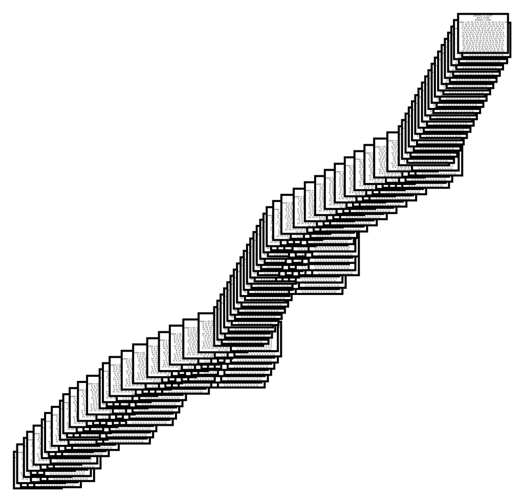

```python
#### Decision Tree depiction on test set classification
from sklearn.tree import DecisionTreeClassifier, plot_tree
fig = plt.gcf()
my_dpi=500
plt.figure(figsize=(2000/my_dpi, 2000/my_dpi), dpi=my_dpi)
treeVis = tree.plot_tree(decAGGmodel_clf.fit(decAGGHOGX_test, decAGGHOGy_test))
```

We see here how the Decision Tree is splitting the images it encounters and assigns them to different classes. Image feature augmented data comes from the test set and the classifier has been trained according to hyperparameters set previously.

### 2.5 Classification on k-means decomposed PCA feature augmented dataset

### 2.5.1 SVM on k-means decomposed PCA feature augmented dataset

```python
#### Training/test set split
from sklearn.model_selection import train_test_split
decPCAX_train, decPCAX_test, decPCAy_train, decPCAy_test = train_test_split(decPCArepo_ros, decPCAtarget_ros,
                                                    stratify=decPCAtarget_ros,
                                                    test_size=0.25, random_state = 40)
```

```python
#### train/test set split proof
print(len(decPCAX_train)," ", decPCAX_train.shape)
print(len(decPCAX_test), " ", decPCAX_test.shape)
print(len(decPCAy_train), " ", decPCAy_train.shape)
print(len(decPCAy_test), " ", decPCAy_test.shape)
```

```
3558   (3558, 9)
1187   (1187, 9)
3558   (3558,)
1187   (1187,)
```

```python
#### Use this cell to train a SVM model to predict the labels of the test data
from sklearn import svm
PCAkm_model_svm  = svm.SVC(gamma='auto', random_state=40)
decPCAclf_svm = PCAkm_model_svm.fit(decPCAX_train, decPCAy_train)
decPCAy_svm = decPCAclf_svm.predict(decPCAX_test)
```

```python
#### Metrics of svm model
import math
from sklearn.metrics import accuracy_score
decPCAaccurSVM = accuracy_score(decPCAy_test,decPCAy_svm)
print('Accuracy of SVM: ', round(decPCAaccurSVM,3))


from sklearn.metrics import recall_score
decPCARecallSc = recall_score(decPCAy_test,decPCAy_svm, average='macro', zero_division=1)
print('Recall of SVM: ', round(decPCARecallSc,3))

from sklearn.metrics import precision_score
decPCApresSVM = precision_score(decPCAy_test,decPCAy_svm, average='macro',zero_division=1)
print('Precision of SVM: ', round(decPCApresSVM,3))

from sklearn.metrics import f1_score
decPCAF1_ScSVM = f1_score(decPCAy_test,decPCAy_svm, average='macro',zero_division=1)
print('F1_score: ', round(decPCAF1_ScSVM,3))


from sklearn.metrics import confusion_matrix, cohen_kappa_score
decPCAkapaSVM = cohen_kappa_score(decPCAy_test, decPCAy_svm)
print('kappa-score: ', round(decPCAkapaSVM, 3))

from sklearn.metrics import matthews_corrcoef
decPCA_MCC_SVM = matthews_corrcoef(decPCAy_test, decPCAy_svm)
print('MCC: ', round(decPCA_MCC_SVM,3))
```

```
Accuracy of SVM:  0.212
Recall of SVM:  0.215
Precision of SVM:  0.668
F1_score:  0.12
kappa-score:  0.2
MCC:  0.205
```

```python
#### Cross validatig the original data (the function will do it all)
from sklearn.model_selection import cross_validate

decPCAcross_val_scores_svm = cross_validate(PCAkm_model_svm, decPCArepo_ros, decPCAtarget_ros, cv=5)
print('SVM cross-validated scores: ', decPCAcross_val_scores_svm)
```

```
SVM cross-validated scores:  {'fit_time': array([1.10405755, 0.96980786, 1.12881994, 1.05079269, 0.9868679 ]), 'score_time': array([0.35715294, 0.39414859, 0.34285545, 0.35577536, 0.46273208]), 'test_score': array([0.12961012, 0.13487882, 0.12223393, 0.17492097, 0.16649104])}
```

```python
from sklearn.model_selection import cross_val_score
#### Evaluating Accuracy for each fold
decPCAvalAccSVM = cross_val_score(PCAkm_model_svm, decPCArepo_ros, decPCAtarget_ros, cv=5, scoring = 'accuracy')
print('Accuracy for SVM: ', decPCAvalAccSVM)

#### Evaluating Mean Accuracy for all folds
print('Mean Accuracy for SVM: ',round(np.mean(decPCAvalAccSVM),2))
```

```
Accuracy for SVM:  [0.12961012 0.13487882 0.12223393 0.17492097 0.16649104]
Mean Accuracy for SVM:  0.15
```

```python
#### Evaluating Precision, Recall and F1-score (both by fold and average)
decPCAprecisionVal_SVM = cross_val_score(PCAkm_model_svm, decPCArepo_ros, decPCAtarget_ros, cv=5, scoring = 'precision_macro')
decMeanPCAprecisionVal_SVM = round(np.mean(decPCAprecisionVal_SVM),2)


decPCArecallVal_SVM = cross_val_score(PCAkm_model_svm, decPCArepo_ros, decPCAtarget_ros, cv=5, scoring = 'recall_macro')
decMeanPCArecallVal_SVM = round(np.mean(decPCArecallVal_SVM),2)

decPCAF1Val_SVM = cross_val_score(PCAkm_model_svm, decPCArepo_ros, decPCAtarget_ros, cv=5, scoring = 'f1_macro')
decMeanPCAF1Val_SVM = round(np.mean(decPCAF1Val_SVM),2)

print('Precision for SVM: ', decPCAprecisionVal_SVM)
print('Mean Precision for SVM: ', decMeanPCAprecisionVal_SVM)
print()
print('Recall for SVM: ', decPCArecallVal_SVM)
print('Mean Recall for SVM: ',decMeanPCArecallVal_SVM)
print()
print('F1-Score for SVM: ', decPCAF1Val_SVM)
print('Mean F1-Score for SVM: ', decMeanPCAF1Val_SVM)
```

```
Precision for SVM:  [0.05564043 0.05196802 0.04824655 0.11081976 0.07372111]
Mean Precision for SVM:  0.07

Recall for SVM:  [0.13516484 0.14065934 0.12637363 0.17970696 0.17252747]
Mean Recall for SVM:  0.15

F1-Score for SVM:  [0.06520574 0.06597676 0.05792346 0.10571281 0.09265297]
Mean F1-Score for SVM:  0.08
```

### 2.5.2 Random Forest on k-means decomposed PCA feature augmented dataset

```python
#### Training RF model to predict the labels of the test data
from sklearn.ensemble import RandomForestClassifier
decPCAmodel_rf = RandomForestClassifier(n_estimators=10,random_state=0)
decPCAclf_rf = decPCAmodel_rf.fit(decPCAX_train, decPCAy_train)
decPCAy_rf = decPCAclf_rf.predict(decPCAX_test)
```

```python
#### Metrics for Random Forest
from sklearn.metrics import accuracy_score
decPCAacc_rf = accuracy_score(decPCAy_test,decPCAy_rf)
print('Accuracy of RF: ', round(decPCAacc_rf,3))

from sklearn.metrics import recall_score
decPCARecallSc_rf = recall_score(decPCAy_test,decPCAy_rf, average='macro')
print('Recall of RF: ', round(decPCARecallSc_rf,3))

from sklearn.metrics import precision_score
decPCApres_rf = precision_score(decPCAy_test, decPCAy_rf,average='macro')
print('Precision of RF: ', round(decPCApres_rf,3))

from sklearn.metrics import f1_score
decPCAF1_Sc_rf = f1_score(decPCAy_test,decPCAy_rf, average='macro')
print('F1_score of RF: ', round(decPCAF1_Sc_rf,3))

from sklearn.metrics import matthews_corrcoef
decPCA_MCC_rf = matthews_corrcoef(decPCAy_test, decPCAy_rf)
print('MCC: ', round(decPCA_MCC_rf,3))

from sklearn.metrics import confusion_matrix, cohen_kappa_score
decPCAkapa_rf = cohen_kappa_score(decPCAy_test, decPCAy_rf)
print('kappa-score: ', round(decPCAkapa_rf, 3))
```

```
Accuracy of RF:  0.805
Recall of RF:  0.806
Precision of RF:  0.825
F1_score of RF:  0.803
MCC:  0.804
kappa-score:  0.802
```

```python
from sklearn.model_selection import cross_val_score
#### Evaluating Accuracy for each fold
decPCAvalAcc_rf = cross_val_score(decPCAmodel_rf, decPCArepo_ros, decPCAtarget_ros, cv=5, scoring = 'accuracy')
print('Accuracy for RF: ', decPCAvalAcc_rf)

#### Evaluating Mean Accuracy for all folds
print('Mean Accuracy for RF: ',round(np.mean(decPCAvalAcc_rf),2))
```

[output not shown]

```python
#### Evaluating Precision, Recall and F1-score (both by fold and average)
decPCAprecisionVal_rf = cross_val_score(decPCAmodel_rf, decPCArepo_ros, decPCAtarget_ros, cv=5, scoring = 'precision_macro')
decMeanPCAprecisionVal_rf = round(np.mean(decPCAprecisionVal_rf),2)


decPCArecallVal_rf = cross_val_score(decPCAmodel_rf, decPCArepo_ros, decPCAtarget_ros, cv=5, scoring = 'recall_macro')
decMeanPCArecallVal_rf = round(np.mean(decPCArecallVal_rf),2)

decPCAF1Val_rf = cross_val_score(decPCAmodel_rf, decPCArepo_ros, decPCAtarget_ros, cv=5, scoring = 'f1_macro')
decMeanPCAF1Val_rf = round(np.mean(decPCAF1Val_rf),2)

print('Precision for RF: ', decPCAprecisionVal_rf)
print('Mean Precision for RF: ', decMeanPCAprecisionVal_rf)
print()
print('Recall for RF: ', decPCArecallVal_rf)
print('Mean Recall for RF: ',decMeanPCArecallVal_rf)
print()
print('F1-Score for RF: ', decPCAF1Val_rf)
print('Mean F1-Score for RF: ', decMeanPCAF1Val_rf)
```

```
Precision for RF:  [0.80558295 0.80886663 0.84168053 0.8284811  0.87751889]
Mean Precision for RF:  0.83

Recall for RF:  [0.78007326 0.77956044 0.82249084 0.80490842 0.84923077]
Mean Recall for RF:  0.81

F1-Score for RF:  [0.77078064 0.77591028 0.81477743 0.80038449 0.84370656]
Mean F1-Score for RF:  0.8
```

### 2.5.3 Decision Trees on k-means decomposed PCA feature augmented dataset

```python
#### Decision tree model training

from sklearn import tree
import math

decPCAmodel_clf = tree.DecisionTreeClassifier(criterion='gini', max_depth=40 ,random_state=40)
decPCAclf_des = decPCAmodel_clf.fit(decPCAX_train, decPCAy_train)
decPCAy_des = decPCAclf_des.predict(decPCAX_test)
```

```python
#### Metrics on Decision Tree
from sklearn.metrics import accuracy_score
decPCAacc_des = accuracy_score(decPCAy_test,decPCAy_des)
print('Accuracy of DT: ', round(decPCAacc_des,3))

from sklearn.metrics import recall_score
decPCARecallSc_des = recall_score(decPCAy_test,decPCAy_des, average='macro', zero_division=1)
print('Recall of DT: ', round(decPCARecallSc_des,3))

from sklearn.metrics import precision_score
decPCApres_des = precision_score(decPCAy_test,decPCAy_des, average='macro',zero_division=1)
print('Precision of DT: ', round(decPCApres_des,3))

from sklearn.metrics import f1_score
decPCAF1_Sc_des = f1_score(decPCAy_test, decPCAy_des,average='macro')
print('F1_score of DT: ', round(decPCAF1_Sc_des,3))

from sklearn.metrics import cohen_kappa_score
decPCAkapa_des = cohen_kappa_score(decPCAy_test, decPCAy_des)
print('kappa-score: ', round(decPCAkapa_des, 3))

from sklearn.metrics import matthews_corrcoef
decPCA_MCC_des = matthews_corrcoef(decPCAy_test, decPCAy_des)
print('MCC: ', round(decPCA_MCC_des,3))
```

```
Accuracy of DT:  0.805
Recall of DT:  0.806
Precision of DT:  0.857
F1_score of DT:  0.803
kappa-score:  0.802
MCC:  0.803
```

```python
from sklearn.model_selection import cross_val_score
#### Evaluating Accuracy for each fold
decPCAvalAcc_des = cross_val_score(decPCAmodel_clf, decPCArepo_ros, decPCAtarget_ros, cv=5, scoring = 'accuracy')
print('Accuracy for DT: ', decPCAvalAcc_des)

#### Evaluating Mean Accuracy for all folds
print('Mean Accuracy for DT: ',round(np.mean(decPCAvalAcc_des),2))
```

```
Accuracy for DT:  [0.7829294  0.7776607  0.81981033 0.79978925 0.84826133]
Mean Accuracy for DT:  0.81
```

```python
#### Evaluating Precision, Recall and F1-score (both by fold and average)
decPCAprecisionVal_des = cross_val_score(decPCAmodel_clf, decPCArepo_ros, decPCAtarget_ros, cv=5, scoring = 'precision_macro')
decMeanPCAprecisionVal_des = round(np.mean(decPCAprecisionVal_des),2)


decPCArecallVal_des = cross_val_score(decPCAmodel_clf, decPCArepo_ros, decPCAtarget_ros, cv=5, scoring = 'recall_macro')
decMeanPCArecallVal_des = round(np.mean(decPCArecallVal_des),2)

decPCAF1Val_des = cross_val_score(decPCAmodel_clf, decPCArepo_ros, decPCAtarget_ros, cv=5, scoring = 'f1_macro')
decMeanPCAF1Val_des = round(np.mean(decPCAF1Val_des),2)

print('Precision for DT: ', decPCAprecisionVal_des)
print('Mean Precision for DT: ', decMeanPCAprecisionVal_des)
print()
print('Recall for DT: ', decPCArecallVal_des)
print('Mean Recall for DT: ',decMeanPCArecallVal_des)
print()
print('F1-Score for DT: ', decPCAF1Val_des)
print('Mean F1-Score for DT: ', decMeanPCAF1Val_des)
```

```
Precision for DT:  [0.80101386 0.80332992 0.8461334  0.82696903 0.87012331]
Mean Precision for DT:  0.83

Recall for DT:  [0.78080586 0.77655678 0.82139194 0.80080586 0.84849817]
Mean Recall for DT:  0.81

F1-Score for DT:  [0.77610435 0.77250955 0.81307442 0.79604252 0.84799703]
Mean F1-Score for DT:  0.8
```

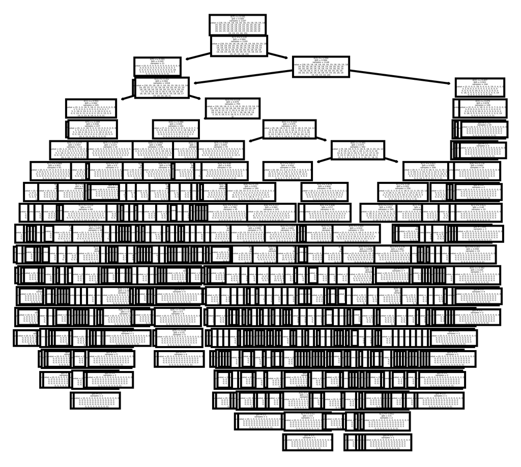

```python
#### Decision Tree depiction on test set classification
from sklearn.tree import DecisionTreeClassifier, plot_tree
fig = plt.gcf()
my_dpi=500
plt.figure(figsize=(2000/my_dpi, 2000/my_dpi), dpi=my_dpi)
treeVis = tree.plot_tree(decPCAmodel_clf.fit(decPCAX_test, decPCAy_test))
```

We see here how the Decision Tree is splitting the images it encounters and assigns them to different classes. Image feature augmented data comes from the test set and the classifier has been trained according to hyperparameters set previously.

### 2.6 Classification on agglomerative clustering decomposed PCA feature augmented dataset

### 2.6.1 SVM on agglomerative clustering decomposed PCA feature augmented dataset

```python
#### Training/test set split
from sklearn.model_selection import train_test_split
PCAdecAGGX_train, PCAdecAGGX_test, PCAdecAGGy_train, PCAdecAGGy_test = train_test_split(AGCdecPCArepo_ros, AGCdecPCAtarget_ros,
                                                    stratify=AGCdecPCAtarget_ros,
                                                    test_size=0.25, random_state = 40)
```

```python
#### train/test set split proof
print(len(PCAdecAGGX_train)," ", PCAdecAGGX_train.shape)
print(len(PCAdecAGGX_test), " ", PCAdecAGGX_test.shape)
print(len(PCAdecAGGy_train), " ", PCAdecAGGy_train.shape)
print(len(PCAdecAGGy_test), " ", PCAdecAGGy_test.shape)
```

```
7020   (7020, 9)
2340   (2340, 9)
7020   (7020,)
2340   (2340,)
```

```python
#### Use this cell to train a SVM model to predict the labels of the test data
from sklearn import svm
PCA_AGGmodel_svm  = svm.SVC(gamma='auto', random_state=40)
PCAdecAGGclf_svm = PCA_AGGmodel_svm.fit(PCAdecAGGX_train, PCAdecAGGy_train)
PCAdecAGGy_svm = PCAdecAGGclf_svm.predict(PCAdecAGGX_test)
```

```python
#### Metrics of svm model
import math
from sklearn.metrics import accuracy_score
PCAdecAGGaccurSVM = accuracy_score(PCAdecAGGy_test,PCAdecAGGy_svm)
print('Accuracy of SVM: ', round(PCAdecAGGaccurSVM,3))


from sklearn.metrics import recall_score
PCAdecAGGRecallSc = recall_score(PCAdecAGGy_test,PCAdecAGGy_svm, average='macro', zero_division=1)
print('Recall of SVM: ', round(PCAdecAGGRecallSc,3))

from sklearn.metrics import precision_score
PCAdecAGGpresSVM = precision_score(PCAdecAGGy_test,PCAdecAGGy_svm, average='macro',zero_division=1)
print('Precision of SVM: ', round(PCAdecAGGpresSVM,3))

from sklearn.metrics import f1_score
PCAdecAGGF1_ScSVM = f1_score(PCAdecAGGy_test,PCAdecAGGy_svm, average='macro',zero_division=1)
print('F1_score: ', round(PCAdecAGGF1_ScSVM,3))


from sklearn.metrics import confusion_matrix, cohen_kappa_score
PCAdecAGGkapaSVM = cohen_kappa_score(PCAdecAGGy_test, PCAdecAGGy_svm)
print('kappa-score: ', round(PCAdecAGGkapaSVM, 3))


from sklearn.metrics import matthews_corrcoef
PCAdecAGG_MCC_SVM = matthews_corrcoef(PCAdecAGGy_test, PCAdecAGGy_svm)
print('MCC: ', round(PCAdecAGG_MCC_SVM,3))
```

```
Accuracy of SVM:  0.363
Recall of SVM:  0.363
Precision of SVM:  0.615
F1_score:  0.266
kappa-score:  0.36
MCC:  0.362
```

```python
from sklearn.model_selection import cross_val_score
#### Evaluating Accuracy for each fold
decAGGHOGvalAccSVM = cross_val_score(PCA_AGGmodel_svm, AGCdecPCArepo_ros, AGCdecPCAtarget_ros, cv=5, scoring = 'accuracy')
print('Accuracy for SVM: ', decAGGHOGvalAccSVM)

#### Evaluating Mean Accuracy for all folds
print('Mean Accuracy for SVM: ',round(np.mean(decAGGHOGvalAccSVM),2))
```

```
Accuracy for SVM:  [0.19123932 0.1917735  0.20138889 0.19444444 0.19391026]
Mean Accuracy for SVM:  0.19
```

```python
#### Evaluating Precision, Recall and F1-score (both by fold and average)
decAGGPCAprecisionVal_SVM = cross_val_score(PCA_AGGmodel_svm, AGCdecPCArepo_ros, AGCdecPCAtarget_ros, cv=5, scoring = 'precision_macro')
decAGGMeanPCAprecisionVal_SVM = round(np.mean(decAGGPCAprecisionVal_SVM),2)


decAGGPCArecallVal_SVM = cross_val_score(PCA_AGGmodel_svm, AGCdecPCArepo_ros, AGCdecPCAtarget_ros, cv=5, scoring = 'recall_macro')
decAGGMeanPCArecallVal_SVM = round(np.mean(decAGGPCArecallVal_SVM),2)

decAGGPCAF1Val_SVM = cross_val_score(PCA_AGGmodel_svm, AGCdecPCArepo_ros, AGCdecPCAtarget_ros, cv=5, scoring = 'f1_macro')
decAGGMeanPCAF1Val_SVM = round(np.mean(decAGGPCAF1Val_SVM),2)

print('Precision for SVM: ', decAGGPCAprecisionVal_SVM)
print('Mean Precision for SVM: ', decAGGMeanPCAprecisionVal_SVM)
print()
print('Recall for SVM: ', decAGGPCArecallVal_SVM)
print('Mean Recall for SVM: ',decMeanPCArecallVal_SVM)
print()
print('F1-Score for SVM: ', decAGGPCAF1Val_SVM)
print('Mean F1-Score for SVM: ', decAGGMeanPCAF1Val_SVM)
```

```
Precision for SVM:  [0.08709436 0.08193726 0.09064795 0.09185592 0.08248938]
Mean Precision for SVM:  0.09

Recall for SVM:  [0.20353276 0.2042735  0.21452991 0.20740741 0.20552707]
Mean Recall for SVM:  0.15

F1-Score for SVM:  [0.10071374 0.10142472 0.10672262 0.10613722 0.10545681]
Mean F1-Score for SVM:  0.1
```

### 2.6.2 Random Forest on agglomerative clustering decomposed PCA feature augmented dataset

```python
#### Training RF model to predict the labels of the test data
from sklearn.ensemble import RandomForestClassifier
PCAdecAGGmodel_rf = RandomForestClassifier(n_estimators=10,random_state=0)
PCAdecAGGclf_rf = PCAdecAGGmodel_rf.fit(PCAdecAGGX_train, PCAdecAGGy_train)
PCAdecAGGy_rf = PCAdecAGGclf_rf.predict(PCAdecAGGX_test)
```

```python
#### Metrics for Random Forest
from sklearn.metrics import accuracy_score
PCAdecAGGacc_rf = accuracy_score(PCAdecAGGy_test,PCAdecAGGy_rf)
print('Accuracy of RF: ', round(PCAdecAGGacc_rf,3))

from sklearn.metrics import recall_score
PCAdecAGGRecallSc_rf = recall_score(PCAdecAGGy_test,PCAdecAGGy_rf, average='macro')
print('Recall of RF: ', round(PCAdecAGGRecallSc_rf,3))

from sklearn.metrics import precision_score
PCAdecAGGpres_rf = precision_score(PCAdecAGGy_test, PCAdecAGGy_rf,average='macro', zero_division=1)
print('Precision of RF: ', round(PCAdecAGGpres_rf,3))

from sklearn.metrics import f1_score
PCAdecAGGF1_Sc_rf = f1_score(PCAdecAGGy_test,PCAdecAGGy_rf, average='macro')
print('F1_score of RF: ', round(PCAdecAGGF1_Sc_rf,3))

from sklearn.metrics import matthews_corrcoef
PCAdecAGG_MCC_rf = matthews_corrcoef(PCAdecAGGy_test, PCAdecAGGy_rf)
print('MCC: ', round(PCAdecAGG_MCC_rf,3))

from sklearn.metrics import confusion_matrix, cohen_kappa_score
PCAdecAGGkapa_rf = cohen_kappa_score(PCAdecAGGy_test, PCAdecAGGy_rf)
print('kappa-score: ', round(PCAdecAGGkapa_rf, 3))
```

```
Accuracy of RF:  0.812
Recall of RF:  0.812
Precision of RF:  0.91
F1_score of RF:  0.796
MCC:  0.814
kappa-score:  0.811
```

```python
from sklearn.model_selection import cross_val_score
#### Evaluating Accuracy for each fold
decAGGHOGvalAcc_rf = cross_val_score(PCAdecAGGmodel_rf, AGCdecPCArepo_ros, AGCdecPCAtarget_ros, cv=5, scoring = 'accuracy')
print('Accuracy for SVM: ', decAGGHOGvalAcc_rf)

#### Evaluating Mean Accuracy for all folds
print('Mean Accuracy for SVM: ',round(np.mean(decAGGHOGvalAcc_rf),2))
```

```
Accuracy for SVM:  [0.80715812 0.79273504 0.81089744 0.82425214 0.82532051]
Mean Accuracy for SVM:  0.81
```

```python
#### Evaluating Precision, Recall and F1-score (both by fold and average)
decAGGPCAprecisionVal_rf = cross_val_score(PCAdecAGGmodel_rf, AGCdecPCArepo_ros, AGCdecPCAtarget_ros, cv=5, scoring = 'precision_macro')
decAGGMeanPCAprecisionVal_rf = round(np.mean(decAGGPCAprecisionVal_rf),2)


decAGGPCArecallVal_rf = cross_val_score(PCAdecAGGmodel_rf, AGCdecPCArepo_ros, AGCdecPCAtarget_ros, cv=5, scoring = 'recall_macro')
decAGGMeanPCArecallVal_rf = round(np.mean(decAGGPCArecallVal_rf),2)

decAGGPCAF1Val_rf = cross_val_score(PCAdecAGGmodel_rf, AGCdecPCArepo_ros, AGCdecPCAtarget_ros, cv=5, scoring = 'f1_macro')
decAGGMeanPCAF1Val_rf = round(np.mean(decAGGPCAF1Val_rf),2)

print('Precision for RF: ', decAGGPCAprecisionVal_rf)
print('Mean Precision for RF: ', decAGGMeanPCAprecisionVal_rf)
print()
print('Recall for RF: ', decAGGPCArecallVal_rf)
print('Mean Recall for RF: ',decAGGMeanPCArecallVal_rf)
print()
print('F1-Score for RF: ', decAGGPCAF1Val_rf)
print('Mean F1-Score for RF: ', decAGGMeanPCAF1Val_rf)
```

```
Precision for RF:  [0.80470051 0.79799338 0.81452299 0.82335813 0.82055789]
Mean Precision for RF:  0.81

Recall for RF:  [0.80569801 0.79464387 0.81219373 0.8239886  0.82461538]
Mean Recall for RF:  0.81

F1-Score for RF:  [0.78931539 0.7769432  0.79665564 0.80908441 0.80834563]
Mean F1-Score for RF:  0.8
```

### 2.6.3 Decision Trees on agglomerative clustering decomposed PCA feature augmented dataset

```python
#### Decision tree model training

from sklearn import tree
import math

PCAdecAGGmodel_clf = tree.DecisionTreeClassifier(criterion='gini', max_depth=70 ,random_state=40)
PCAdecAGGclf_des = PCAdecAGGmodel_clf.fit(PCAdecAGGX_train, PCAdecAGGy_train)
PCAdecAGGy_des = PCAdecAGGclf_des.predict(PCAdecAGGX_test)
```

```python
#### Metrics on Decision Tree
from sklearn.metrics import accuracy_score
PCAdecAGGacc_des = accuracy_score(PCAdecAGGy_test,PCAdecAGGy_des)
print('Accuracy of DT: ', round(PCAdecAGGacc_des,3))

from sklearn.metrics import recall_score
PCAdecAGGRecallSc_des = recall_score(PCAdecAGGy_test,PCAdecAGGy_des, average='macro', zero_division=1)
print('Recall of DT: ', round(PCAdecAGGRecallSc_des,3))

from sklearn.metrics import precision_score
PCAdecAGGpres_des = precision_score(PCAdecAGGy_test,PCAdecAGGy_des, average='macro',zero_division=1)
print('Precision of DT: ', round(PCAdecAGGpres_des,3))

from sklearn.metrics import f1_score
PCAdecAGGF1_Sc_des = f1_score(PCAdecAGGy_test, PCAdecAGGy_des,average='macro')
print('F1_score of DT: ', round(PCAdecAGGF1_Sc_des,3))

from sklearn.metrics import cohen_kappa_score
PCAdecAGGkapa_des = cohen_kappa_score(PCAdecAGGy_test, PCAdecAGGy_des)
print('kappa-score: ', round(PCAdecAGGkapa_des, 3))

from sklearn.metrics import matthews_corrcoef
PCAdecAGG_MCC_des = matthews_corrcoef(PCAdecAGGy_test, PCAdecAGGy_des)
print('MCC: ', round(PCAdecAGG_MCC_des,3))
```

```
Accuracy of DT:  0.811
Recall of DT:  0.811
Precision of DT:  0.909
F1_score of DT:  0.794
kappa-score:  0.81
MCC:  0.812
```

```python
from sklearn.model_selection import cross_val_score
#### Evaluating Accuracy for each fold
decAGGPCAvalAcc_des = cross_val_score(PCAdecAGGmodel_clf, AGCdecPCArepo_ros, AGCdecPCAtarget_ros, cv=5, scoring = 'accuracy')
print('Accuracy for DT: ', decAGGPCAvalAcc_des)

#### Evaluating Mean Accuracy for all folds
print('Mean Accuracy for DT: ',round(np.mean(decAGGPCAvalAcc_des),2))
```

```
Accuracy for DT:  [0.80715812 0.78899573 0.81089744 0.82211538 0.8258547 ]
Mean Accuracy for DT:  0.81
```

```python
#### Evaluating Precision, Recall and F1-score (both by fold and average)
decAGGPCAprecisionVal_des = cross_val_score(PCAdecAGGmodel_clf, AGCdecPCArepo_ros, AGCdecPCAtarget_ros, cv=5, scoring = 'precision_macro')
decAGGMeanPCAprecisionVal_des = round(np.mean(decAGGPCAprecisionVal_des),2)


decAGGPCArecallVal_des = cross_val_score(PCAdecAGGmodel_clf, AGCdecPCArepo_ros, AGCdecPCAtarget_ros, cv=5, scoring = 'recall_macro')
decAGGMeanPCArecallVal_des = round(np.mean(decAGGPCArecallVal_des),2)

decAGGPCAF1Val_des = cross_val_score(PCAdecAGGmodel_clf, AGCdecPCArepo_ros, AGCdecPCAtarget_ros, cv=5, scoring = 'f1_macro')
decAGGMeanPCAF1Val_des = round(np.mean(decAGGPCAF1Val_des),2)

print('Precision for DT: ', decAGGPCAprecisionVal_des)
print('Mean Precision for DT: ', decAGGMeanPCAprecisionVal_des)
print()
print('Recall for DT: ', decAGGPCArecallVal_des)
print('Mean Recall for DT: ',decAGGMeanPCArecallVal_des)
print()
print('F1-Score for DT: ', decAGGPCAF1Val_des)
print('Mean F1-Score for DT: ', decAGGMeanPCAF1Val_des)
```

```
Precision for DT:  [0.80426995 0.79216277 0.81410057 0.82510087 0.822671  ]
Mean Precision for DT:  0.81

Recall for DT:  [0.80678063 0.79145299 0.81327635 0.82296296 0.82632479]
Mean Recall for DT:  0.81

F1-Score for DT:  [0.7896141  0.77425458 0.79738068 0.80713061 0.80853651]
Mean F1-Score for DT:  0.8
```

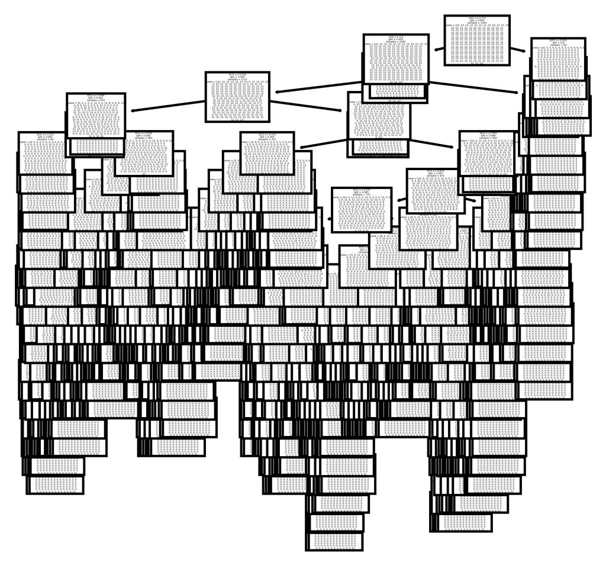

```python
#### Decision Tree depiction on test set classification
from sklearn.tree import DecisionTreeClassifier, plot_tree
fig = plt.gcf()
my_dpi=500
plt.figure(figsize=(2000/my_dpi, 2000/my_dpi), dpi=my_dpi)
treeVis = tree.plot_tree(PCAdecAGGmodel_clf.fit(PCAdecAGGX_test, PCAdecAGGy_test))
```

We see here how the Decision Tree is splitting the images it encounters and assigns them to different classes. Image feature augmented data comes from the test set and the classifier has been trained according to hyperparameters set previously.